# Estimación multi-contaminante de la calidad del aire en Chile

- Mostrar todo el código
- Ocultar todo el código
- Ver el código fuente

Metodología, análisis descriptivo y validación de modelos de estimación horaria de PM₂.₅, PM₁₀, NO₂, O₃, SO₂ y CO — modelos globales de satélite+química calibrados contra la red SINCA, 2019–2024

Autor/a

Proyecto AFG1 · Estimación multi-contaminante de la calidad del aire en Chile

Fecha de publicación

1 de septiembre de 2026

## 1 Resumen y alcance

Este documento desarrolla, de principio a fin, la estimación de concentraciones superficiales horarias de seis contaminantes del aire en Chile continental — PM₂.₅, PM₁₀, NO₂, O₃, SO₂ y CO — combinando **modelos globales de satélite+química** (GEOS-CF, CAMS EAC4, ACAG) con la **red de monitoreo SINCA** como referencia de calibración y validación. La receta metodológica es la dominante en la literatura de exposición: un modelo físico-químico corregido estadísticamente contra estaciones de monitoreo (van Donkelaar et al., 2016; Di et al., 2019; Wei et al., 2021), aquí implementada con tres motores de calibración comparables — **regresión geográficamente ponderada (GWR)**, **gradient boosting (LightGBM)** y **regression-kriging (RK)** — más el modelo físico crudo como referencia sin calibrar.

El documento está ordenado como una tesis: primero la **metodología completa** (Sección 2), con la operacionalización de todas las variables, las fórmulas de los tres motores y los protocolos de evaluación; luego el **análisis descriptivo** (Sección 3) — las series de tiempo de cada contaminante según los modelos globales, después según los monitores SINCA, y la correlación diaria entre ambos, siempre a nivel nacional, por macrozona y por región; en seguida los **modelos y sus métricas** (Sección 4) a esos mismos tres niveles; y al cierre las **series de tiempo de los modelos calibrados contra SINCA** (Sección 5) y sus **gráficos de correlación** (Sección 6).

**Decisiones de esta iteración**

- **Resolución horaria** (estación × hora UTC, 2019–2024): más exigente que la diaria que domina la literatura; toda métrica se reporta también agregada a medias diarias.
- **Validación fuera-de-estación (LOSO)** como vara principal, complementada con el *protocolo del producto* (modelo final entrenado con todas las estaciones, acuerdo diario in-situ) — dos preguntas distintas, dos números distintos (Sección 2.7).
- **Caché reproducible**: cada artefacto pesado vive en `output_files/`; si el archivo existe, el chunk que lo produce se salta el cómputo. Para regenerar algo, se borra el artefacto y se vuelve a renderizar.

## 2 Metodología

### 2.1 Diseño del estudio y área

La red SINCA (Sistema de Información Nacional de Calidad del Aire, MMA) aporta las estaciones de referencia. Tras el control de calidad de coordenadas (Sección 2.2.1) quedan **105 estaciones válidas** distribuidas en las 15 regiones tradicionales (según codificación SINCA). Para el análisis por niveles se usan tres agregaciones espaciales anidadas: **nacional**, **macrozona** (cinco zonas climático-geográficas estándar) y **región**.

Tabla 1: Macrozonas del estudio y su composición regional.

| Macrozona | Regiones (código SINCA) |
| --- | --- |
| Norte Grande | Arica y Parinacota (RXV), Tarapacá (RI), Antofagasta (RII) |
| Norte Chico | Atacama (RIII), Coquimbo (RIV) |
| Centro | Valparaíso (RV), Metropolitana (RM), O’Higgins (RVI), Maule (RVII) |
| Sur | Biobío–Ñuble (RVIII), Araucanía (RIX), Los Ríos (RXIV), Los Lagos (RX) |
| Austral | Aysén (RXI), Magallanes (RXII) |

**Configuración: rutas, contaminantes, unidades, macrozonas y caché**

```python
"""Configuración global: rutas del repo, contaminantes, unidades y caché.

El notebook vive en ``docs/``, así que la raíz del repo es su padre. Todo
artefacto pesado se cachea en ``output_files/``: si el archivo existe, el
chunk que lo produce se salta el cómputo (borrar el artefacto = regenerarlo).
"""
from __future__ import annotations

import json
import os
import warnings
from pathlib import Path
from zoneinfo import ZoneInfo

import numpy as np
import pandas as pd

warnings.filterwarnings("ignore", category=FutureWarning)

def _encontrar_raiz() -> Path:
    """Raíz del repo: sube desde el cwd hasta hallar data/ y output_files/."""
    if os.environ.get("AFG_REPO_ROOT"):
        return Path(os.environ["AFG_REPO_ROOT"]).resolve()
    p = Path.cwd().resolve()
    for cand in [p, *p.parents]:
        if (cand / "data").exists() and (cand / "output_files").exists():
            return cand
    return p

RAIZ = _encontrar_raiz()
DATA = RAIZ / "data"
SINCA_DIR = DATA / "sinca"
CONT = DATA / "contaminantes"
SMOKE = os.environ.get("AFG_SMOKE", "0") == "1"      # corrida corta de prueba
OUT = RAIZ / "output_files" / ("_smoke" if SMOKE else "")
FIGS = OUT / "figures"
FIGS.mkdir(parents=True, exist_ok=True)

TZ_CL = ZoneInfo("America/Santiago")   # SINCA reporta hora local

# Contaminantes objetivo, sus unidades SINCA y rangos físicos plausibles
CONTAMINANTES = ["pm25", "pm10", "no2", "o3", "so2", "co"]
UNIDADES = {"pm25": "µg/m³", "pm10": "µg/m³", "no2": "ppb",
            "o3": "ppb", "so2": "ppb", "co": "ppm"}
RANGO_VALIDO = {"pm25": (0, 1500), "pm10": (0, 3000), "no2": (0, 1000),
                "o3": (0, 500), "so2": (0, 3000), "co": (0, 60)}

# Macrozonas (5) a partir del código de región SINCA
MACROZONA = {
    "RXV": "norte_grande", "RI": "norte_grande", "RII": "norte_grande",
    "RIII": "norte_chico", "RIV": "norte_chico",
    "RV": "centro", "RM": "centro", "RVI": "centro", "RVII": "centro",
    "RVIII": "sur", "RIX": "sur", "RXIV": "sur", "RX": "sur",
    "RXI": "austral", "RXII": "austral",
}

# Perillas de ejecución (sobre-escribibles por variable de entorno)
MAX_FILAS_TRAIN = int(os.environ.get("AFG_MAX_TRAIN_ROWS", "300000"))
N_ARBOLES = int(os.environ.get("AFG_N_TREES", "600"))
SEMILLA = 42

def cache_parquet(ruta: Path, generar):
    """Devuelve el DataFrame cacheado en `ruta`, o lo genera y lo guarda."""
    if ruta.exists():
        return pd.read_parquet(ruta)
    df = generar()
    ruta.parent.mkdir(parents=True, exist_ok=True)
    df.to_parquet(ruta, index=False)
    return df

def leer_estaciones() -> tuple[pd.DataFrame, pd.DataFrame]:
    """Metadatos de estaciones; separa las que no tienen coordenadas válidas
    (p. ej. Concón MMA viene con lat/lon = inf en estaciones.csv)."""
    est = pd.read_csv(SINCA_DIR / "estaciones.csv")
    est["estacion"] = est["estacion"].astype(str)
    est["macrozona"] = est["region_sinca"].map(MACROZONA)
    est[["lat", "lon"]] = est[["lat", "lon"]].replace([np.inf, -np.inf], np.nan)
    # 4 estaciones vienen con coordenadas corruptas en estaciones.csv
    # (Concón MMA inf; Quintero lat 56,6/lon 114,9; La Palma lon −44;
    # Entre Lagos lon −78,6): filtro por el bbox de Chile continental.
    lon_min, lat_min, lon_max, lat_max = (-76.0, -56.5, -66.0, -17.0)
    validas = (est["lat"].between(lat_min, lat_max)
               & est["lon"].between(lon_min, lon_max))
    return (est[validas].reset_index(drop=True),
            est[~validas].reset_index(drop=True))

ESTACIONES, ESTACIONES_EXCLUIDAS = leer_estaciones()
```

**Resumen del alcance resuelto**

```python
from IPython.display import Image, Markdown
_NOMBRE_LEGIBLE = {"pm25": "PM₂.₅", "pm10": "PM₁₀", "no2": "NO₂",
                   "o3": "O₃", "so2": "SO₂", "co": "CO"}
pd.DataFrame({
    "contaminante": [_NOMBRE_LEGIBLE[p] for p in CONTAMINANTES],
    "unidad": [UNIDADES[p] for p in CONTAMINANTES],
    "rango físico admitido": [f"{RANGO_VALIDO[p][0]} – {RANGO_VALIDO[p][1]}"
                              for p in CONTAMINANTES],
}).set_index("contaminante")
```

Tabla 2: Alcance del estudio: contaminantes, unidades y rangos de plausibilidad.

| contaminante | unidad | rango físico admitido |
| --- | --- | --- |
| PM₂.₅ | µg/m³ | 0 – 1500 |
| PM₁₀ | µg/m³ | 0 – 3000 |
| NO₂ | ppb | 0 – 1000 |
| O₃ | ppb | 0 – 500 |
| SO₂ | ppb | 0 – 3000 |
| CO | ppm | 0 – 60 |

Periodo **2019–2024** · **105** estaciones con coordenadas válidas (4 excluidas por coordenadas corruptas, Sección 8).

### 2.2 Operacionalización de variables

El estudio maneja siete bloques de variables: la **respuesta** (observación SINCA), los **modelos globales** de satélite+química, la **meteorología** de reanálisis, el **AOD satelital**, las **covariables estáticas** de superficie, el **calendario** y las variables **geoestadísticas** derivadas de la propia red. La tabla siguiente operacionaliza cada variable; las subsecciones detallan las transformaciones no triviales con sus fórmulas.

Tabla 3: Operacionalización de las variables del estudio.

| Variable | Código | Definición operacional | Fuente | Resolución | Unidades | Transformación |
| --- | --- | --- | --- | --- | --- | --- |
| Concentración observada | `obs` | Concentración del contaminante en la estación; mejor dato disponible con precedencia *validado ≻ preliminar ≻ no validado* | SINCA / MMA | estación · horaria (hora local al inicio) | µg/m³ (PM), ppb (NO₂, O₃, SO₂), ppm (CO) | coma decimal → punto; hora local → UTC; filtro de rango físico (Tabla 4) |
| Concentraciones GEOS-CF (PM₂.₅, NO₂, O₃, SO₂, CO) | `gcf_*` | Concentración simulada por GEOS-CF (colección `aqc_tavg_1hr`, promedio horario) en el píxel de la estación | NASA GMAO, GEOS-CF v1 | 0,25° · horaria (estampa :30 → inicio de hora) | µg/m³, ppb, ppm | normalización de unidades por archivo; máscara de rellenos; mol/mol → ppb (×10⁹) / ppm CO (×10⁶) |
| Concentraciones CAMS EAC4 (PM₂.₅, PM₁₀, NO₂, O₃, SO₂, CO) | `cams_*` | Concentración del reanálisis CAMS EAC4 en el píxel de la estación | ECMWF / Copernicus | 0,75° · 3-horaria → interpolada a 1 h (límite 2 pasos) | µg/m³, ppb, ppm | razón de masa → mezcla en volumen (Ecuación 3); kg/m³ → µg/m³ (×10⁹); longitudes 0–360° → −180–180° |
| PM₂.₅ satelital anual | `acag_pm25` | PM₂.₅ superficial anual del producto CNN ACAG V6GL03 en el píxel | ACAG, Washington Univ. | 0,01° · anual | µg/m³ | valor del año calendario asignado a cada hora |
| Temperatura 2 m; humedad relativa 2 m; viento zonal y meridional 10 m; presión superficial; altura de capa límite; AOD y PM₂.₅ de reanálisis | `T2M`, `RH2M`, `U10M`, `V10M`, `PS`, `PBLH`, `AOD_M2`, `PM25_M2` | Meteorología de reanálisis agregada a comuna; cada estación hereda el valor de su comuna | MERRA-2 (pre-procesado comunal) | 0,5° × 0,625° → comuna · horaria | K, %, m/s, m/s, Pa, m, adim., µg/m³ | `fecha_local`+`hora` → UTC (convención verificada con el ciclo diurno de PBLH) |
| AOD y PM₂.₅ de reanálisis **por estación** | `m2_aod`, `m2_pm25` | Espesor óptico total y masa superficial de PM₂.₅ (polvo, sal, carbono negro y orgánico ×1,4, sulfato ×1,375) del reanálisis de aerosoles, en el píxel de la estación | MERRA-2 M2T1NXAER (recorte Chile) | 0,5° × 0,625° · horaria (estampa :30 → inicio de hora) | adim., µg/m³ | kg/m³ → µg/m³ (×10⁹) |
| Distancia a la megafuente SO₂ más cercana | `dist_fuente_km` | Distancia haversine a la fundición / termoeléctrica / refinería más cercana | tabla de fuentes (RETC aprox.) | estación · fija | km | Ecuación 4 |
| Carga de fuentes SO₂ | `carga_fuentes_so2` | Potencial de emisión Σ E/d² de las megafuentes | tabla de fuentes | estación · fija | log | Ecuación 4 |
| Viento desde fuentes SO₂ | `viento_fuentes_so2` | Carga ponderada por la alineación del viento horario con la dirección fuente → estación | tabla de fuentes + MERRA-2 | estación · horaria | log | Ecuación 5 |
| AOD satelital MAIAC | `aod_maiac` | Espesor óptico de aerosol a 550 nm por pasada, agregado a comuna | MODIS MAIAC MCD19A2 | 1 km → comuna · por pasada (hora UTC) | adim. | media comunal por pasada |
| Fracción urbana y de pastizal | `frac_urbano`, `frac_grassland` | Fracción del área comunal con cada cobertura de suelo | cobertura de suelo (pre-procesado comunal) | comuna · fija | fracción | — |
| Densidad de red vial | `vial_osm` | Densidad de la red vial de la comuna | OpenStreetMap | comuna · fija | índice | — |
| Altitud media y distancia a costa | `alt_media`, `dist_costa_km` | Topografía comunal | DEM / topografía comunal | comuna · fija | m, km | — |
| Hora y día del año cíclicos | `hora_sin`, `hora_cos`, `doy_sin`, `doy_cos` | Codificación cíclica de la hora local y del día del año | derivada | horaria | adim. | Ecuación 6 |
| Día de semana, mes, año, hora local | `dow`, `mes`, `anio`, `hora_loc` | Componentes de calendario en reloj local | derivada | horaria | — | — |
| Franja horaria | `franja` | Ventana diurna (08–18 h local) vs. nocturna | derivada | horaria | — | — |
| Observación de estaciones vecinas | `obs_vec` | Observación concurrente interpolada desde las **demás** estaciones (IDW gaussiano) | SINCA | estación · horaria | unidad del contaminante | Ecuación 7 |
| Peso del vecindario | `peso_vec` | Suma de pesos del vecindario informante (0 = sin vecinos con dato) | derivada | estación · horaria | adim. | Ecuación 7 |
| Inverso de la capa límite | `inv_pblh` | Inverso de la altura de capa de mezcla | MERRA-2 | comuna · horaria | m⁻¹ | $1/\max(\mathrm{PBLH},50)$ |
| Dilución del modelo físico | `fis_div_pblh` | Modelo físico principal diluido por la capa de mezcla | mixta | horaria | — | físico / PBLH |
| Dilución del PM₂.₅ de reanálisis | `pm25m2_pblh` | PM₂.₅ MERRA-2 diluido por la capa de mezcla | MERRA-2 | comuna · horaria | — | PM25_M2 / PBLH |
| Crecimiento higroscópico | `frh` | Factor de crecimiento higroscópico del aerosol | MERRA-2 | comuna · horaria | adim. | Ecuación 8 |
| Rapidez del viento | `wind` | Magnitud del viento a 10 m | MERRA-2 | comuna · horaria | m/s | $\sqrt{U_{10}^2+V_{10}^2}$ |
| AOD «seco» | `aod_div_frh` | AOD desinflado por humedad | MAIAC / MERRA-2 | comuna · horaria | adim. | AOD / $f_{RH}$ |
| Latitud y longitud | `lat`, `lon` | Coordenadas de la estación (WGS84) | SINCA | estación · fija | grados | solo como insumo del boosting |

#### 2.2.1 Variable respuesta: monitoreo SINCA

Cada serie horaria SINCA se exporta con tres columnas de calidad (`validado`, `preliminar`, `no_validado`) y separador decimal de coma. La observación operacional toma, hora a hora, el **mejor dato disponible**:

$$\mathrm{obs}_{s,t} \;=\;
\begin{cases}
\text{validado}_{s,t} & \text{si existe}\\
\text{preliminar}_{s,t} & \text{si no hay validado}\\
\text{no validado}_{s,t} & \text{en último término}
\end{cases}
\qquad(1)$$

donde $\mathrm{obs}_{s,t}$ es la concentración operacional de la estación $s$ en la hora $t$. La precedencia responde al ciclo de validación del MMA: el dato *validado* llega con rezago de meses a años, así que exigirlo excluiría los años recientes; el *preliminar* y el *no validado* completan la serie con la mejor información disponible en cada momento, y la columna de origen queda registrada. Los valores usan coma decimal en el archivo fuente y se convierten a punto flotante estándar.

La estampa temporal SINCA es **hora local continental al inicio del intervalo** (la fila «14:00» promedia 14:00–15:00); se convierte a UTC con la zona oficial `America/Santiago`, cambios de hora incluidos: $t_{\mathrm{UTC}} = \mathrm{tz}^{-1}(t_{\mathrm{local}})$, donde las horas ambiguas o inexistentes del cambio de hora se marcan como faltantes en vez de adivinarse. Se descartan los valores fuera de rango físico plausible:

Tabla 4: Rangos de plausibilidad física aplicados a la observación.

| Contaminante | Rango válido | Unidad |
| --- | --- | --- |
| PM₂.₅ | 0 – 1500 | µg/m³ |
| PM₁₀ | 0 – 3000 | µg/m³ |
| NO₂ | 0 – 1000 | ppb |
| O₃ | 0 – 500 | ppb |
| SO₂ | 0 – 3000 | ppb |
| CO | 0 – 60 | ppm |

Cuatro estaciones traen coordenadas corruptas en el maestro de estaciones (*Concón MMA*, *Quintero*, *La Palma*, *Entre Lagos*) y quedan excluidas por el filtro de caja geográfica del dominio (Sección 8).

**Lector SINCA: parseo, coma decimal, hora local → UTC, rangos válidos**

```python
def leer_sinca_serie(ruta: Path) -> pd.DataFrame:
    """Parsea un CSV del exportador SINCA (``FECHA;HORA;validado;preliminar;no_validado``).

    Toma el primer valor no vacío entre las tres columnas de registro
    (validado → preliminar → no validado) y usa coma decimal cuando aparece.
    Devuelve columnas [ts_local, obs] con ts_local naive (hora local Chile).
    """
    df = pd.read_csv(ruta, sep=";", header=0, dtype=str,
                     names=["fecha", "hora", "v1", "v2", "v3", "extra"],
                     usecols=range(6), skiprows=1, engine="c")
    obs = df["v1"].where(df["v1"].str.len() > 0, df["v2"])
    obs = obs.where(obs.str.len() > 0, df["v3"])
    obs = pd.to_numeric(obs.str.replace(",", ".", regex=False), errors="coerce")
    ts = pd.to_datetime(df["fecha"] + df["hora"], format="%y%m%d%H%M",
                        errors="coerce")
    out = pd.DataFrame({"ts_local": ts, "obs": obs}).dropna(subset=["ts_local"])
    return out

def leer_sinca(pol: str) -> pd.DataFrame:
    """Serie horaria SINCA de un contaminante, todas las estaciones, en UTC.

    La hora local (America/Santiago) se convierte a UTC; las horas ambiguas
    o inexistentes por el cambio de hora se descartan (≈2 h/año/estación).
    """
    filas = []
    for ruta in sorted((SINCA_DIR / pol / "horario").glob("*.csv")):
        region, estacion = ruta.stem.split("_")[:2]
        s = leer_sinca_serie(ruta)
        if s["obs"].notna().sum() == 0:
            continue
        s["estacion"] = estacion
        filas.append(s)
    df = pd.concat(filas, ignore_index=True)
    loc = df["ts_local"].dt.tz_localize(TZ_CL, ambiguous="NaT",
                                        nonexistent="NaT")
    df["ts"] = loc.dt.tz_convert("UTC").dt.tz_localize(None)
    df = df.dropna(subset=["ts"])
    lo, hi = RANGO_VALIDO[pol]
    df.loc[(df["obs"] < lo) | (df["obs"] > hi), "obs"] = np.nan
    return df[["estacion", "ts", "obs"]].dropna()
```

**Cobertura SINCA por contaminante**

```python
_filas = []
for _pol in CONTAMINANTES:
    _o = leer_sinca(_pol)
    _filas.append({"contaminante": _NOMBRE_LEGIBLE[_pol],
                   "unidad": UNIDADES[_pol],
                   "estaciones": _o["estacion"].nunique(),
                   "filas horarias": len(_o),
                   "desde": str(_o["ts"].min())[:10],
                   "hasta": str(_o["ts"].max())[:10]})
pd.DataFrame(_filas).set_index("contaminante")
```

Tabla 5: Cobertura de la observación SINCA por contaminante (2019–2024).

| contaminante | unidad | estaciones | filas horarias | desde | hasta |
| --- | --- | --- | --- | --- | --- |
| PM₂.₅ | µg/m³ | 99 | 4464992 | 2019-01-01 | 2025-01-01 |
| PM₁₀ | µg/m³ | 78 | 3621024 | 2019-01-01 | 2025-01-01 |
| NO₂ | ppb | 46 | 1986518 | 2019-01-01 | 2025-01-01 |
| O₃ | ppb | 45 | 1922193 | 2019-01-01 | 2025-01-01 |
| SO₂ | ppb | 46 | 2024158 | 2019-01-01 | 2025-01-01 |
| CO | ppm | 40 | 1701520 | 2019-01-01 | 2025-01-01 |

#### 2.2.2 Modelos globales de satélite+química

Los «modelos satelitales» del estudio son dos sistemas globales que asimilan observaciones satelitales en un modelo de química atmosférica, más un producto satelital anual de alta resolución:

- **GEOS-CF v1** (NASA GMAO): composición atmosférica horaria a 0,25°, colección `aqc_tavg_1hr` (promedio horario estampado a la media hora; se lleva al inicio de hora para calzar con SINCA). Los gases vienen en fracción molar y se convierten a partes por billón (CO a ppm):

$$\chi_{\mathrm{ppb}} = \chi_{\mathrm{mol/mol}} \times 10^{9}, \qquad
\chi^{\mathrm{CO}}_{\mathrm{ppm}} = \chi^{\mathrm{CO}}_{\mathrm{mol/mol}}
\times 10^{6}
\qquad(2)$$

El servidor OPeNDAP entrega algunos meses ya convertidos (ppb, µg/m³) y otros en unidades nativas (mol/mol, kg/m³), además de valores de relleno sin decodificar ($\sim 10^{15}$). La normalización es por archivo: se enmascara $|x|>10^{13}$ y se detecta la unidad por la mediana del mes (mediana $>10^{-3}$ en gases ⇒ ya está en ppb). GEOS-CF `aqc` no incluye PM₁₀, por lo que ese contaminante se apoya solo en CAMS.

- **CAMS EAC4** (ECMWF/Copernicus): reanálisis global de composición, 3-horario a 0,75°, interpolado linealmente a paso horario (máximo dos pasos). Los gases vienen como razón de masa $q$ (kg/kg) y se convierten a mezcla en volumen; el material particulado viene como densidad (kg/m³):

$$\chi_{\mathrm{ppb}} = q\,\frac{M_{\mathrm{aire}}}{M_{\mathrm{gas}}}\times
10^{9},
\qquad
c_{\mu\mathrm{g/m^3}} = \rho_{\mathrm{kg/m^3}} \times 10^{9}
\qquad(3)$$

con $M_{\mathrm{aire}} = 28{,}9647$ g/mol y $M_{\mathrm{gas}}$ = 46,0055 (NO₂), 47,9982 (O₃), 64,066 (SO₂) y 28,0101 (CO) g/mol. Las longitudes del archivo de gases (0–360°) se llevan a −180–180°.

- **ACAG V6GL03** (Atmospheric Composition Analysis Group): PM₂.₅ superficial **anual** a 0,01°, producto CNN que fusiona satélite, modelo y monitores; cada estación toma el píxel más cercano y hereda el valor del año calendario. Actúa como *prior* espacial fino solo para PM₂.₅.

En todos los casos la co-localización es por **vecino más cercano** del píxel a las coordenadas de la estación.

**Lectores GEOS-CF / CAMS EAC4 / ACAG / MERRA-2 y tabla compartida**

```python
# Extracción de los modelos físicos (GEOS-CF horario 0.25°, CAMS EAC4 3 h 0.75°)
# y del producto ACAG (PM2.5 superficie anual 0.01°) en las coordenadas de cada
# estación. Todo queda en UNA tabla horaria compartida estación × hora UTC.

M_AIRE = 28.9647  # g/mol
M_GAS = {"no2": 46.0055, "o3": 47.9982, "so2": 64.066, "co": 28.0101}

def _puntos_xr(ds, lats, lons, lat="lat", lon="lon"):
    import xarray as xr
    return ds.sel({lat: xr.DataArray(lats, dims="est"),
                   lon: xr.DataArray(lons, dims="est")}, method="nearest")

def _escala_geoscf(df: pd.DataFrame) -> pd.DataFrame:
    """Normaliza unidades por archivo: el OPeNDAP de GEOS-CF sirve algunos
    meses con gases en mol/mol y PM2.5 en kg/m³, y otros ya convertidos a
    ppb/µg-m⁻³. Se detecta por magnitud (mediana) y se lleva todo a
    mol/mol y µg/m³ antes de la conversión final. Enmascara además los
    valores de relleno sin decodificar (≈1e15) que a veces trae el OPeNDAP."""
    for v in ["o3", "no2", "so2", "co", "pm25_rh35_gcc"]:
        df.loc[df[v].abs() > 1e13, v] = np.nan
    for v in ["o3", "no2", "so2", "co"]:
        med = float(np.nanmedian(df[v]))
        if med > 1e-3:                 # ya viene en ppb → devolver a mol/mol
            df[v] = df[v] * 1e-9
    med = float(np.nanmedian(df["pm25_rh35_gcc"]))
    if med < 1e-3:                     # viene en kg/m³ → µg/m³
        df["pm25_rh35_gcc"] = df["pm25_rh35_gcc"] * 1e9
    return df

def extraer_geoscf(est: pd.DataFrame) -> pd.DataFrame:
    """GEOS-CF (aqc_tavg_1hr): gases en mol/mol → ppb (CO → ppm), PM2.5 µg/m³."""
    import xarray as xr
    archivos = sorted((CONT / "GEOS_CF" / "raw_chile").glob("geoscf_*.nc"))
    if SMOKE:
        archivos = archivos[:2]
    partes = []
    for f in archivos:
        with xr.open_dataset(f) as ds:
            ds = ds.squeeze(drop=True)
            sub = _puntos_xr(ds, est["lat"].values, est["lon"].values)
            df = sub.to_dataframe().reset_index()
        partes.append(_escala_geoscf(df))
    g = pd.concat(partes, ignore_index=True)
    g["estacion"] = est["estacion"].values[g["est"].values]
    g = g.rename(columns={"time": "ts"})
    # tavg1: promedio de la hora estampado a la media hora (00:30 = 00–01 h);
    # se lleva al inicio de hora para calzar con SINCA (hora de inicio)
    g["ts"] = g["ts"].dt.floor("h")
    for v, col in [("no2", "gcf_no2"), ("o3", "gcf_o3"), ("so2", "gcf_so2")]:
        g[col] = g[v] * 1e9                       # mol/mol → ppb
    g["gcf_co"] = g["co"] * 1e6                   # mol/mol → ppm
    g["gcf_pm25"] = g["pm25_rh35_gcc"]            # ya en µg/m³
    cols = ["estacion", "ts", "gcf_pm25", "gcf_no2", "gcf_o3", "gcf_so2", "gcf_co"]
    return g[cols]

def extraer_cams(est: pd.DataFrame) -> pd.DataFrame:
    """CAMS EAC4 (3-horario): gases kg/kg → ppb (CO → ppm), PM kg/m³ → µg/m³.

    Los archivos de gases usan longitud 0–360 y los de PM −180–180; ambos se
    llevan a puntos de estación y luego se interpola linealmente a paso horario
    (huecos de máximo 2 h entre pasos de 3 h).
    """
    import xarray as xr
    base = CONT / "CAMS_EAC4" / "raw_chile"
    anios = sorted({f.stem[-4:] for f in base.glob("cams_eac4_gas_*.nc")})
    if SMOKE:
        anios = anios[:1]
    partes = []
    for anio in anios:
        with xr.open_dataset(base / f"cams_eac4_gas_{anio}.nc") as g:
            g = g.squeeze(drop=True)
            # los archivos de gases vienen en longitud 0–360: convertir las
            # longitudes de estación (negativas) a esa convención
            lons = est["lon"].values % 360 if float(g.longitude.min()) >= 0 \
                else est["lon"].values
            sub = _puntos_xr(g, est["lat"].values, lons,
                             lat="latitude", lon="longitude")
            dfg = sub.to_dataframe().reset_index()
        with xr.open_dataset(base / f"cams_eac4_pm_{anio}.nc") as p:
            subp = _puntos_xr(p, est["lat"].values, est["lon"].values,
                              lat="latitude", lon="longitude")
            dfp = subp.to_dataframe().reset_index()
        for df in (dfg, dfp):
            df["estacion"] = est["estacion"].values[df["est"].values]
        dfg = dfg.rename(columns={"valid_time": "ts"})
        dfp = dfp.rename(columns={"valid_time": "ts"})
        m = dfg.merge(dfp[["estacion", "ts", "pm2p5", "pm10"]],
                      on=["estacion", "ts"], how="outer")
        partes.append(m)
    c = pd.concat(partes, ignore_index=True)
    for gas, col in [("no2", "cams_no2"), ("go3", "cams_o3"), ("so2", "cams_so2")]:
        c[col] = c[gas] * (M_AIRE / M_GAS[col.split("_")[1]]) * 1e9   # kg/kg → ppb
    c["cams_co"] = c["co"] * (M_AIRE / M_GAS["co"]) * 1e6             # kg/kg → ppm
    c["cams_pm25"] = c["pm2p5"] * 1e9                                 # kg/m³ → µg/m³
    c["cams_pm10"] = c["pm10"] * 1e9
    cols = ["estacion", "ts", "cams_pm25", "cams_pm10", "cams_no2",
            "cams_o3", "cams_so2", "cams_co"]
    c = c[cols].sort_values(["estacion", "ts"])
    # 3 h → 1 h por interpolación lineal dentro de cada estación
    horas = pd.date_range(c["ts"].min(), c["ts"].max(), freq="h")
    llenas = []
    for estacion, grupo in c.groupby("estacion", sort=False):
        g = grupo.set_index("ts").reindex(horas)
        g[cols[2:]] = g[cols[2:]].interpolate(method="linear", limit=2)
        g["estacion"] = estacion
        llenas.append(g.rename_axis("ts").reset_index())
    return pd.concat(llenas, ignore_index=True)[cols]

def extraer_acag(est: pd.DataFrame) -> pd.DataFrame:
    """ACAG V6GL03 (CNN PM2.5 superficie, anual, 0.01°) en cada estación."""
    import xarray as xr
    filas = []
    for f in sorted((CONT / "ACAG_V6GL03" / "raw_chile").glob("V6GL03.CNNPM25.SA.*01-*12.nc")):
        anio = int(f.stem.split(".")[-1][:4])
        with xr.open_dataset(f) as ds:
            sub = _puntos_xr(ds, est["lat"].values, est["lon"].values)
            vals = np.asarray(sub["PM25"].values, dtype=float)
        filas.append(pd.DataFrame({"estacion": est["estacion"].values,
                                   "anio": anio, "acag_pm25": vals}))
    if not filas:
        return pd.DataFrame(columns=["estacion", "anio", "acag_pm25"])
    return pd.concat(filas, ignore_index=True)

def extraer_merra2(est: pd.DataFrame) -> pd.DataFrame | None:
    """MERRA-2 aerosoles horarios (M2T1NXAER, recorte Chile) — opcional.

    Se incluye solo si ≥90 % de los días 2019–2024 están descargados en
    ``data/contaminantes/M2TMNXAER.5.12.4/raw_chile`` (en esta corrida puede
    omitirse). Aporta AOD total y masas superficiales de especies para PM.
    """
    import xarray as xr
    base = CONT / "M2TMNXAER.5.12.4" / "raw_chile"
    archivos = sorted(base.glob("MERRA2_*.tavg1_2d_aer_Nx.*.chile.nc4"))
    dias_esperados = pd.date_range("2019-01-01", "2024-12-31", freq="D").size
    if len(archivos) < 0.9 * dias_esperados:
        return None
    variables = ["TOTEXTTAU", "DUSMASS25", "SSSMASS25", "BCSMASS",
                 "OCSMASS", "SO4SMASS"]
    partes = []
    for f in archivos:
        with xr.open_dataset(f) as ds:
            pres = [v for v in variables if v in ds]
            sub = _puntos_xr(ds[pres], est["lat"].values, est["lon"].values)
            df = sub.to_dataframe().reset_index()
        df["estacion"] = est["estacion"].values[df["est"].values]
        partes.append(df)
    m = pd.concat(partes, ignore_index=True).rename(columns={"time": "ts"})
    # tavg1: promedio horario estampado a la media hora → inicio de hora
    m["ts"] = m["ts"].dt.floor("h")
    m["m2_aod"] = m.get("TOTEXTTAU")
    # masa superficial de PM2.5 por especies (kg/m³ → µg/m³), receta MERRA-2
    comp = (m.get("DUSMASS25", 0) + m.get("SSSMASS25", 0) + m.get("BCSMASS", 0)
            + 1.4 * m.get("OCSMASS", 0) + 1.375 * m.get("SO4SMASS", 0))
    m["m2_pm25"] = comp * 1e9
    return m[["estacion", "ts", "m2_aod", "m2_pm25"]]

def tabla_predictores() -> pd.DataFrame:
    """Tabla horaria compartida estación × hora UTC con todos los predictores."""
    def _generar():
        est = ESTACIONES
        g = extraer_geoscf(est)
        c = extraer_cams(est)
        t = g.merge(c, on=["estacion", "ts"], how="outer")
        a = extraer_acag(est)
        if len(a):
            t["anio"] = t["ts"].dt.year
            t = t.merge(a, on=["estacion", "anio"], how="left").drop(columns="anio")
        m2 = extraer_merra2(est)
        if m2 is not None:
            t = t.merge(m2, on=["estacion", "ts"], how="left")
        for c in t.columns:
            if t[c].dtype == np.float64:
                t[c] = t[c].astype(np.float32)
        return t
    return cache_parquet(OUT / "predictores_estaciones_horario.parquet", _generar)
```

#### 2.2.3 Meteorología y covariables comunales

La meteorología entra pre-procesada a nivel de **comuna × hora** desde el repositorio de datos hermano del proyecto: ocho variables MERRA-2 (T2M, RH2M, U10M, V10M, PS, PBLH, AOD y PM₂.₅ del propio reanálisis), el AOD MAIAC por pasada agregado a comuna, y cinco covariables estáticas de superficie (fracción urbana, fracción de pastizal, densidad vial OSM, altitud media y distancia a costa). Cada estación **hereda el valor de su comuna** — una aproximación aceptable dada la resolución nativa de 0,5° del reanálisis. La estampa `fecha_local`+`hora` se convierte a UTC con la zona oficial; la convención quedó verificada contrastando el máximo diurno de la altura de capa límite (PBLH) con la hora solar. Si estos insumos no están disponibles en el entorno de ejecución, el pipeline continúa sin ellos (auto-detección).

**Insumos comunales: met MERRA-2, MAIAC, estáticas y cod_comuna**

```python
# Insumos comunales pre-procesados: meteorología MERRA-2 agregada a comuna ×
# hora (T2M, RH2M, U10M, V10M, PS, PBLH, AOD y PM2.5 MERRA-2), AOD MAIAC
# comunal por pasada y covariables estáticas (fracción urbana, red vial,
# topografía). Se leen del repositorio de datos hermano
# (../Neurodegen-Epidemiology-Chile, o AFG_NEURO_ROOT); si no están, el
# pipeline sigue sin ellas (auto-detección, como MERRA-2).

def _neuro_root() -> Path | None:
    cand = [Path(os.environ["AFG_NEURO_ROOT"])] if os.environ.get("AFG_NEURO_ROOT") else []
    cand += [RAIZ.parent / "Neurodegen-Epidemiology-Chile"]
    for c in cand:
        if c.exists():
            return c
    return None

def _leer_dbf(path: Path, enc: str = "utf-8") -> pd.DataFrame:
    """Lector mínimo de DBF (atributos de shapefile) sin dependencias."""
    import struct
    data = path.read_bytes()
    n_rec = struct.unpack("<I", data[4:8])[0]
    hdr_sz, rec_sz = struct.unpack("<HH", data[8:12])
    campos, off = [], 32
    while data[off] != 0x0D:
        nombre = data[off:off + 11].split(b"\x00")[0].decode("latin1")
        campos.append((nombre, data[off + 16])); off += 32
    filas, p = [], hdr_sz
    for _ in range(n_rec):
        rec = data[p:p + rec_sz]; p += rec_sz
        if not rec or rec[0:1] == b"*":
            continue
        v, q = {}, 1
        for nombre, flen in campos:
            v[nombre] = rec[q:q + flen].decode(enc, errors="replace").strip(); q += flen
        filas.append(v)
    return pd.DataFrame(filas)

def _norm_nombre(s: str) -> str:
    import unicodedata
    s = unicodedata.normalize("NFKD", str(s)).encode("ascii", "ignore").decode().lower()
    return "".join(ch for ch in s if ch.isalnum())

def mapear_cod_comuna(est: pd.DataFrame) -> pd.Series:
    """cod_comuna oficial por estación (nombre de comuna → shapefile de comunas)."""
    nr = _neuro_root()
    if nr is None or not (nr / "data" / "comunas.dbf").exists():
        return pd.Series(np.nan, index=est.index)
    dbf = _leer_dbf(nr / "data" / "comunas.dbf")
    dbf["k"] = dbf["Comuna"].map(_norm_nombre)
    mapa = dict(zip(dbf["k"], pd.to_numeric(dbf["cod_comuna"], errors="coerce")))
    return est["comuna"].map(_norm_nombre).map(mapa)

MET_COMUNAL_VARS = ["T2M", "RH2M", "U10M", "V10M", "PS", "PBLH",
                    "AOD_M2", "PM25_M2"]

def extraer_met_comunal(est: pd.DataFrame) -> pd.DataFrame | None:
    """Meteorología MERRA-2 comuna × hora del repo neuro → estación × hora UTC.

    El parquet trae ``fecha_local`` + ``hora`` (reloj de Chile continental):
    se convierte a UTC con la zona oficial. Se lee con filtro por comuna
    (solo las comunas con estación) para no cargar 63 M de filas.
    """
    nr = _neuro_root()
    ruta = (nr / "output_files" / "merra2_comunal_horario.parquet") if nr else None
    if ruta is None or not ruta.exists():
        return None
    import pyarrow.parquet as pq
    cods = mapear_cod_comuna(est)
    validos = sorted(set(cods.dropna().astype(int)))
    tabla = pq.read_table(ruta, filters=[("cod_comuna", "in", validos)])
    met = tabla.to_pandas()
    ts_loc = (pd.to_datetime(met["fecha_local"])
              + pd.to_timedelta(met["hora"].astype(int), unit="h"))
    loc = ts_loc.dt.tz_localize(TZ_CL, ambiguous="NaT", nonexistent="NaT")
    met["ts"] = loc.dt.tz_convert("UTC").dt.tz_localize(None)
    met = met.dropna(subset=["ts"])
    met = met[(met["ts"] >= "2018-12-31") & (met["ts"] <= "2025-01-02")]
    pres = [v for v in MET_COMUNAL_VARS if v in met.columns]
    met = met[["cod_comuna", "ts"] + pres]
    for c in pres:
        met[c] = met[c].astype(np.float32)
    liga = pd.DataFrame({"estacion": est["estacion"].values,
                         "cod_comuna": cods.values}).dropna()
    liga["cod_comuna"] = liga["cod_comuna"].astype(int)
    out = liga.merge(met, on="cod_comuna", how="left")
    return out.drop(columns="cod_comuna")

def extraer_maiac_comunal(est: pd.DataFrame) -> pd.DataFrame | None:
    """AOD MAIAC comuna × pasada (CSV por año del repo neuro) → estación × hora UTC.

    Cada fila es una pasada Terra/Aqua con ``fecha`` + ``hora_utc``; se
    promedian pasadas coincidentes. La columna resultante ``aod_maiac`` es
    rala por construcción (solo horas con pasada y cielo despejado) — LightGBM
    maneja los NaN de forma nativa.
    """
    nr = _neuro_root()
    base = (nr / "data" / "contaminantes" / "MCD19A2.061" / "comunal_horario") if nr else None
    if base is None or not base.exists():
        return None
    archivos = [base / f"maiac_aod_comunal_horario_{a}.csv" for a in range(2019, 2025)]
    archivos = [f for f in archivos if f.exists()]
    if not archivos:
        return None
    cods = mapear_cod_comuna(est)
    validos = set(cods.dropna().astype(int))
    partes = []
    for f in archivos:
        df = pd.read_csv(f, usecols=["cod_comuna", "fecha", "hora_utc",
                                     "aod055_media"])
        df = df[df["cod_comuna"].isin(validos)]
        hh = df["hora_utc"].astype(str).str.slice(0, 2).astype(int)
        df["ts"] = pd.to_datetime(df["fecha"]) + pd.to_timedelta(hh, unit="h")
        partes.append(df.groupby(["cod_comuna", "ts"], as_index=False)
                      ["aod055_media"].mean()
                      .rename(columns={"aod055_media": "aod_maiac"}))
    aod = pd.concat(partes, ignore_index=True)
    liga = pd.DataFrame({"estacion": est["estacion"].values,
                         "cod_comuna": cods.values}).dropna()
    liga["cod_comuna"] = liga["cod_comuna"].astype(int)
    out = liga.merge(aod, on="cod_comuna", how="left")
    return out.drop(columns="cod_comuna")

def extraer_estaticas(est: pd.DataFrame) -> pd.DataFrame | None:
    """Covariables estáticas por comuna (fracción urbana/pastizal, red vial OSM,
    altitud media y distancia a costa) del repo neuro → por estación."""
    nr = _neuro_root()
    if nr is None:
        return None
    rutas = {"estaticas": nr / "output_files" / "estaticas_comunales_nac.csv",
             "topo": nr / "data" / "contaminantes" / "Topografia" / "topografia_comunal.csv"}
    if not rutas["estaticas"].exists():
        return None
    cods = mapear_cod_comuna(est)
    liga = pd.DataFrame({"estacion": est["estacion"].values,
                         "cod_comuna": cods.values}).dropna()
    liga["cod_comuna"] = liga["cod_comuna"].astype(int)
    s = pd.read_csv(rutas["estaticas"])
    out = liga.merge(s, on="cod_comuna", how="left")
    if rutas["topo"].exists():
        t = pd.read_csv(rutas["topo"])[["cod_comuna", "alt_media", "dist_costa_km"]]
        out = out.merge(t, on="cod_comuna", how="left")
    return out.drop(columns="cod_comuna")
```

#### 2.2.4 Fuentes puntuales de SO₂

El SO₂ chileno es, en su mayor parte, una señal de **fuente puntual**: fundiciones de cobre, centrales termoeléctricas a carbón y refinerías. Sin saber dónde están los emisores respecto de cada estación, ningún modelo puede extrapolar esa señal a un sitio no observado. La tabla `data/fuentes_so2.csv` lista las megafuentes del periodo —siete fundiciones, siete complejos termoeléctricos y dos refinerías— con sus coordenadas y un **peso relativo de emisión** $E_k$ (orden de magnitud, refinable con el inventario RETC). De ella se derivan tres covariables por estación $s$:

$$\mathrm{dist\_fuente}_s=\min_k d_{sk},\qquad
\mathrm{carga}_s=\log\!\Big(1+\sum_k \frac{E_k}{\max(d_{sk},2)^{2}}\Big)
\qquad(4)$$

$$\mathrm{viento\_fuentes}_{s,t}=\log\!\Big(1+\sum_k \frac{E_k}{\max(d_{sk},2)^{2}}
\,\max\!\big(0,\ u_{s,t}\,\hat x_{sk}+v_{s,t}\,\hat y_{sk}\big)\Big)
\qquad(5)$$

donde $d_{sk}$ es la distancia haversine entre la estación y la fuente $k$ (acotada por abajo a 2 km para no divergir), $(\hat x_{sk},\hat y_{sk})$ el versor **desde la fuente hacia la estación** y $(u,v)$ las componentes del viento a 10 m de la hora (MERRA-2). La carga es un potencial gravitacional de emisión —crece con fuentes pesadas y cercanas—; la variable direccional es grande solo cuando el viento sopla *desde* una fuente pesada y cercana *hacia* la estación (producto escalar positivo), y vale cero con viento en contra: es la firma de estar viento abajo de una chimenea. Las tres entran al boosting; el modelo aprende su relevancia por contaminante (para SO₂ son la información que faltaba; para CO y NO₂ las termoeléctricas también aportan).

**Fuentes puntuales de SO₂: distancia, carga y alineación del viento**

```python
# Covariables de FUENTES PUNTUALES de SO₂ (fundiciones, termoeléctricas,
# refinerías). El diagnóstico LOSO muestra que la señal de SO₂ es de fuente
# puntual: sin saber dónde están los emisores, ningún motor generaliza a
# estaciones no vistas. La tabla ``data/fuentes_so2.csv`` lista las
# megafuentes con coordenadas y un peso relativo de emisión (orden de
# magnitud, refinable con RETC); de ella se derivan tres covariables por
# estación: distancia a la fuente más cercana, carga gravitacional Σ E/d²
# y — con el viento horario — la alineación direccional fuente → estación
# (¿está la estación viento abajo de una fuente pesada y cercana?).

def cargar_fuentes_so2() -> pd.DataFrame | None:
    ruta = DATA / "fuentes_so2.csv"
    if not ruta.exists():
        return None
    return pd.read_csv(ruta)

def _geometria_fuentes(est: pd.DataFrame):
    """Distancias (km) y versores fuente→estación para cada par."""
    f = cargar_fuentes_so2()
    if f is None or not len(f):
        return None
    la_e = est["lat"].to_numpy(float)[:, None]     # (n_est, 1)
    lo_e = est["lon"].to_numpy(float)[:, None]
    la_f = f["lat"].to_numpy(float)[None, :]       # (1, n_f)
    lo_f = f["lon"].to_numpy(float)[None, :]
    D = haversine_km(la_e, lo_e, la_f, lo_f)       # (n_est, n_f)
    # componentes planas locales del vector fuente→estación
    dx = (lo_e - lo_f) * 111.32 * np.cos(np.radians((la_e + la_f) / 2))
    dy = (la_e - la_f) * 110.57
    norma = np.sqrt(dx ** 2 + dy ** 2)
    norma[norma < 1e-6] = 1e-6
    ux, uy = dx / norma, dy / norma
    peso = f["peso_so2"].to_numpy(float)[None, :]
    W = peso / np.maximum(D, 2.0) ** 2             # carga gravitacional
    return {"D": D, "ux": ux, "uy": uy, "W": W}

def agregar_fuentes_so2(p: pd.DataFrame) -> pd.DataFrame:
    """Agrega las covariables de fuentes puntuales al panel.

    Estáticas por estación: ``dist_fuente_km`` (a la fuente más cercana) y
    ``carga_fuentes_so2`` = log(1 + Σ_k E_k/d_k²). Horaria (si hay viento
    MERRA-2): ``viento_fuentes_so2`` = log(1 + Σ_k (E_k/d_k²) ·
    max(0, u·x̂_k + v·ŷ_k)) — grande cuando el viento sopla DESDE una
    fuente pesada y cercana HACIA la estación."""
    geo = _geometria_fuentes(ESTACIONES)
    if geo is None:
        return p
    est_codes = ESTACIONES["estacion"].astype(str).to_numpy()
    idx_de = {e: i for i, e in enumerate(est_codes)}
    idx = p["estacion"].astype(str).map(idx_de)
    ok = idx.notna().to_numpy()
    fila_est = idx.fillna(0).astype(int).to_numpy()
    p["dist_fuente_km"] = np.where(
        ok, geo["D"].min(axis=1)[fila_est], np.nan).astype(np.float32)
    p["carga_fuentes_so2"] = np.where(
        ok, np.log1p(geo["W"].sum(axis=1))[fila_est], np.nan).astype(np.float32)
    if {"U10M", "V10M"}.issubset(p.columns):
        u = p["U10M"].to_numpy(np.float32)
        v = p["V10M"].to_numpy(np.float32)
        acc = np.zeros(len(p), dtype=np.float32)
        for k in range(geo["D"].shape[1]):
            proy = (u * geo["ux"][fila_est, k].astype(np.float32)
                    + v * geo["uy"][fila_est, k].astype(np.float32))
            acc += geo["W"][fila_est, k].astype(np.float32) * np.clip(proy, 0, None)
        p["viento_fuentes_so2"] = np.where(ok, np.log1p(acc), np.nan
                                           ).astype(np.float32)
    return p
```

### 2.3 Construcción del panel analítico

El panel de modelamiento de cada contaminante es el *inner join* de la observación SINCA con la tabla compartida de predictores (estación × hora UTC), enriquecido con calendario, vecinas y derivadas físicas:

1. **Calendario cíclico.** La hora local $h$ y el día del año $\mathrm{doy}$ se codifican en el círculo para que 23:00 y 00:00 —o el 31 de diciembre y el 1 de enero— queden contiguos:

$$\mathrm{hora\_sin}=\sin\frac{2\pi h}{24},\quad
\mathrm{hora\_cos}=\cos\frac{2\pi h}{24},\quad
\mathrm{doy\_sin}=\sin\frac{2\pi\,\mathrm{doy}}{365{,}25},\quad
\mathrm{doy\_cos}=\cos\frac{2\pi\,\mathrm{doy}}{365{,}25}
\qquad(6)$$

2. **Observación de las estaciones vecinas** (insumo geoestadístico estándar de la interpolación espacial con árboles, tipo RFSI). Para la estación $i$ en la hora $t$, con $o_j(t)$ la observación de la estación $j$ y $\mathbf{1}[o_j(t)]$ su indicador de disponibilidad:

$$w_{ij}=\exp\!\left[-\left(\frac{d_{ij}}{h}\right)^{2}\right],\quad h=150
\text{ km},\quad w_{ii}=0;\qquad
\mathrm{obs\_vec}_i(t)=\frac{\sum_{j} w_{ij}\,o_j(t)\,\mathbf{1}[o_j(t)]}
{\sum_{j} w_{ij}\,\mathbf{1}[o_j(t)]}
\qquad(7)$$

donde $w_{ij}$ es el peso gaussiano entre las estaciones $i$ y $j$, $d_{ij}$ su distancia haversine (Ecuación 15), $h$ el alcance fijo de 150 km, $o_j(t)$ la observación de la estación $j$ en la hora $t$ y $\mathbf{1}[o_j(t)]$ el indicador de que esa observación existe (1 si hay dato, 0 si no). Como la diagonal es nula ($w_{ii}=0$), la estación **nunca se ve a sí misma**: la variable es válida bajo validación fuera-de-estación y computable en cualquier punto del territorio al generar superficie. `peso_vec` (el denominador, $\sum_j w_{ij}\,\mathbf{1}[o_j(t)]$) mide cuán informado está el vecindario: vale cerca de 0 en una estación aislada u horas en que las vecinas no reportan, y crece con la densidad local de la red — el propio boosting aprende a descontar `obs_vec` cuando `peso_vec` es bajo.

3. **Derivadas físico-informadas** de la literatura AOD→PM: dilución por capa de mezcla ($1/\mathrm{PBLH}$, físico/PBLH), crecimiento higroscópico

$$f_{RH}=\frac{1}{1-\min(RH,97)/100}
\qquad(8)$$

rapidez de viento $\sqrt{U_{10}^2+V_{10}^2}$ (ventilación) y AOD desinflado por humedad ($\mathrm{AOD}/f_{RH}$).

El panel se compacta a `float32`/categorías y se cachea por contaminante; las filas exigen presencia del modelo físico principal.

**Ensamblaje del panel horario por contaminante (cacheado)**

```python
# Panel de modelamiento por contaminante: observación SINCA + predictores +
# calendario (hora local, día del año, día de semana) + coordenadas.

FISICO = {   # columnas de modelo físico por contaminante: [principal, secundaria]
    "pm25": ["gcf_pm25", "cams_pm25"],
    "pm10": ["cams_pm10"],                # GEOS-CF aqc no trae PM10
    "no2":  ["gcf_no2", "cams_no2"],
    "o3":   ["gcf_o3", "cams_o3"],
    "so2":  ["gcf_so2", "cams_so2"],
    "co":   ["gcf_co", "cams_co"],
}
TODAS_FUENTES = ["gcf_pm25", "gcf_no2", "gcf_o3", "gcf_so2", "gcf_co",
                 "cams_pm25", "cams_pm10", "cams_no2", "cams_o3",
                 "cams_so2", "cams_co"]

def agregar_calendario(df: pd.DataFrame) -> pd.DataFrame:
    ts_loc = (df["ts"].dt.tz_localize("UTC").dt.tz_convert(TZ_CL)
              .dt.tz_localize(None))
    h = ts_loc.dt.hour + ts_loc.dt.minute / 60
    doy = ts_loc.dt.dayofyear
    df["hora_sin"] = np.sin(2 * np.pi * h / 24)
    df["hora_cos"] = np.cos(2 * np.pi * h / 24)
    df["doy_sin"] = np.sin(2 * np.pi * doy / 365.25)
    df["doy_cos"] = np.cos(2 * np.pi * doy / 365.25)
    df["dow"] = ts_loc.dt.dayofweek.astype("int8")
    df["anio"] = ts_loc.dt.year.astype("int16")
    df["hora_loc"] = ts_loc.dt.hour.astype("int8")
    df["mes"] = ts_loc.dt.month.astype("int8")
    df["franja"] = np.where(df["hora_loc"].between(8, 18), "diurna", "nocturna")
    return df

def feats_fisicos(p: pd.DataFrame, pol: str) -> pd.DataFrame:
    """Features físico-informados estándar de la literatura AOD→PM:
    dilución masa/altura de mezcla (PBLH),
    crecimiento higroscópico f(RH), viento (ventilación) y AOD desinflado por
    humedad. Solo se crean si la meteorología comunal está disponible."""
    if "PBLH" in p:
        pblh = p["PBLH"].clip(lower=50.0)
        p["inv_pblh"] = 1.0 / pblh
        p["fis_div_pblh"] = p[FISICO[pol][0]] / pblh
        if "PM25_M2" in p:
            p["pm25m2_pblh"] = p["PM25_M2"] / pblh
    if "RH2M" in p:
        rh = p["RH2M"].clip(upper=97.0)
        rh = np.where(rh > 1.5, rh, rh * 100.0)      # acepta % o fracción
        p["frh"] = 1.0 / (1.0 - np.clip(rh, 0, 97) / 100.0)
    if {"U10M", "V10M"}.issubset(p.columns):
        p["wind"] = np.sqrt(p["U10M"] ** 2 + p["V10M"] ** 2)
    for aod in ["aod_maiac", "AOD_M2", "m2_aod"]:
        if aod in p and "frh" in p:
            p["aod_div_frh"] = p[aod] / p["frh"]
            break
    return p

def agregar_vecinas(p: pd.DataFrame, h_km: float = 150.0) -> pd.DataFrame:
    """Observación concurrente interpolada desde las DEMÁS estaciones (IDW
    gaussiano, diagonal en cero) — el insumo geoestadístico estándar de la
    interpolación espacial con bosques/boosting (p. ej. RFSI). Para la
    estación s en la hora t usa solo estaciones ≠ s, así que es válida bajo
    LOSO y calculable en cualquier comuna al generar la superficie.

    Agrega: ``obs_vec`` (interpolación) y ``peso_vec`` (suma de pesos =
    cuán informado está el vecindario; 0 = sin vecinos con dato).
    """
    O = p.pivot_table(index="ts", columns="estacion", values="obs",
                      aggfunc="mean")
    cols = O.columns.to_numpy()
    meta = ESTACIONES.set_index("estacion").loc[cols]
    lat, lon = meta["lat"].to_numpy(float), meta["lon"].to_numpy(float)
    D = haversine_km(lat[:, None], lon[:, None], lat[None, :], lon[None, :])
    W = np.exp(-(D / h_km) ** 2)
    np.fill_diagonal(W, 0.0)
    M = O.notna().to_numpy(float)
    V = np.nan_to_num(O.to_numpy(float))
    num = V @ W
    den = M @ W
    with np.errstate(invalid="ignore", divide="ignore"):
        idw = np.where(den > 0, num / den, np.nan)
    largo = pd.DataFrame(idw.astype(np.float32), index=O.index,
                         columns=cols).stack(future_stack=True)
    pesos = pd.DataFrame(den.astype(np.float32), index=O.index,
                         columns=cols).stack(future_stack=True)
    extra = pd.DataFrame({"obs_vec": largo, "peso_vec": pesos}).reset_index()
    extra.columns = ["ts", "estacion", "obs_vec", "peso_vec"]
    return p.merge(extra, on=["ts", "estacion"], how="left")

def _compactar(p: pd.DataFrame) -> pd.DataFrame:
    """float64 → float32 y texto → category: el panel horario cabe en RAM."""
    for c in p.columns:
        if p[c].dtype == np.float64:
            p[c] = p[c].astype(np.float32)
        elif p[c].dtype == object:
            p[c] = p[c].astype("category")
    return p

def construir_panel(pol: str) -> pd.DataFrame:
    """Panel horario listo para modelar (cacheado en output_files/)."""
    def _generar():
        import gc
        obs = leer_sinca(pol)
        pred = tabla_predictores()
        p = obs.merge(pred, on=["estacion", "ts"], how="inner")
        del obs, pred; gc.collect()
        # inner: solo estaciones con coordenadas válidas (ver leer_estaciones)
        p = p.merge(ESTACIONES[["estacion", "lat", "lon", "region_sinca",
                                "macrozona", "comuna"]], on="estacion", how="inner")
        p = agregar_calendario(p)
        p = agregar_vecinas(p)
        p = _compactar(p); gc.collect()
        met = extraer_met_comunal(ESTACIONES)
        if met is not None:
            p = p.merge(met, on=["estacion", "ts"], how="left")
            del met; gc.collect()
        aodm = extraer_maiac_comunal(ESTACIONES)
        if aodm is not None:
            p = p.merge(aodm, on=["estacion", "ts"], how="left")
            del aodm
        estat = extraer_estaticas(ESTACIONES)
        if estat is not None:
            p = p.merge(estat, on="estacion", how="left")
        p = agregar_fuentes_so2(p)
        p = feats_fisicos(p, pol)
        p = _compactar(p); gc.collect()
        # exige el modelo físico principal presente
        p = p.dropna(subset=[FISICO[pol][0]])
        return p
    ruta = OUT / f"panel_{pol}_horario.parquet"
    return cache_parquet(ruta, _generar)
```

**Cobertura de la tabla compartida de predictores**

```python
_ruta = OUT / "resumen_predictores.csv"
(pd.read_csv(_ruta)
   .rename(columns={"filas_con_dato": "filas con dato",
                    "cobertura_pct": "cobertura (%)"})
   .set_index("fuente")
 if _ruta.exists()
 else Markdown("_(resumen aún no generado en este entorno)_"))
```

Tabla 6: Cobertura por fuente de la tabla compartida de predictores (estación × hora UTC).

| fuente | columnas | filas con dato | cobertura (%) | desde | hasta |
| --- | --- | --- | --- | --- | --- |
| GEOS-CF (gcf_*) | 5 | 5523735 | 100.0 | 2019-01-01 | 2024-12-31 |
| CAMS EAC4 (cams_*) | 6 | 5523630 | 100.0 | 2019-01-01 | 2024-12-31 |
| ACAG anual (acag_pm25) | 1 | 5523840 | 100.0 | 2019-01-01 | 2024-12-31 |
| MERRA-2 aerosol por estación (m2_*) | 2 | 5523840 | 100.0 | 2019-01-01 | 2024-12-31 |
| TOTAL estación × hora | 14 | 5523840 | 100.0 | 2019-01-01 | 2024-12-31 |

### 2.4 Métricas de evaluación

Para un conjunto de pares observación–predicción $(y_i,\hat y_i)$ se reportan:

$$R^{2} = 1-\frac{\sum_i (y_i-\hat y_i)^{2}}{\sum_i (y_i-\bar y)^{2}}
\qquad\text{(coeficiente de determinación, penaliza sesgo y escala)}
\qquad(9)$$

$$r^{2} = \left[\frac{\operatorname{Cov}(y,\hat y)}
{\sigma_y\,\sigma_{\hat y}}\right]^{2}
\qquad\text{(cuadrado de la correlación de Pearson, invariante a recta)}
\qquad(10)$$

$$\mathrm{RMSE}=\sqrt{\tfrac{1}{n}\sum_i (y_i-\hat y_i)^{2}},\qquad
\mathrm{MAE}=\tfrac{1}{n}\sum_i |y_i-\hat y_i|,\qquad
\mathrm{sesgo}=\tfrac{1}{n}\sum_i (\hat y_i-y_i)
\qquad(11)$$

donde $y_i$ es la observación, $\hat y_i$ la predicción, $\bar y$ la media de las observaciones del conjunto evaluado, $\sigma$ las desviaciones estándar y $n$ el número de pares válidos (ambos valores finitos; con menos de 3 pares la métrica se declara indefinida). Dos propiedades importan para leer los resultados: (i) el $R^2$ **puede ser negativo** — significa que el modelo lo hace peor que predecir la media observada, situación frecuente en el modelo físico crudo y en estaciones atípicas bajo LOSO —, y (ii) $r^2$ es invariante a transformaciones lineales ($r^2 \geq R^2$ siempre), por lo que un producto puede correlacionar bien y aun así estar sesgado; por eso se reportan ambos junto con el sesgo aditivo.

Las **métricas diarias** se calculan sobre las medias por estación–día, $\bar y_{s,d}=\frac{1}{|H_{s,d}|}\sum_{t\in H_{s,d}} y_{s,t}$, donde $H_{s,d}$ es el conjunto de horas con dato de la estación $s$ en el día $d$; la predicción se agrega con la misma regla y sobre las mismas horas, de modo que ambos promedios son directamente comparables. Las métricas **por nivel** (nacional / macrozona / región) restringen los pares al nivel correspondiente. Se distinguen siempre dos lecturas: el **R² agrupado** (todas las horas del nivel juntas, premia acertar los niveles entre estaciones) y el **R² mediano por estación** (la mediana, entre estaciones del nivel, del R² calculado dentro de cada estación; mide habilidad temporal y es sistemáticamente más exigente).

**Primitivas compartidas de gráficos y métricas**

```python
# Primitivas compartidas de gráficos y métricas (se definen antes
# del análisis descriptivo y de la validación, que las reutilizan).
import matplotlib
matplotlib.use("Agg")
import matplotlib.pyplot as plt

plt.rcParams.update({
    "figure.dpi": 150, "font.size": 10, "axes.titlesize": 12,
    "axes.titleweight": "bold", "axes.spines.top": False,
    "axes.spines.right": False, "axes.grid": True, "grid.alpha": 0.25,
    # Tipografía Arial (o su equivalente métrico Liberation Sans)
    "font.family": "sans-serif",
    "font.sans-serif": ["Arial", "Liberation Sans", "Helvetica",
                        "DejaVu Sans"],
})
AZUL, NARANJO, VERDE, ROJO, MORADO = ("#4C72B0", "#DD8452", "#55A868",
                                      "#C44E52", "#8172B3")
COLOR_MOTOR = {"fisico": "#9a9a9a", "gwr": AZUL, "rk": VERDE, "lgbm": NARANJO}
NOMBRE_MOTOR = {"fisico": "Modelo físico crudo", "gwr": "GWR",
                "rk": "Regression-kriging", "lgbm": "LightGBM"}
NOMBRE_POL = {"pm25": "PM$_{2.5}$", "pm10": "PM$_{10}$", "no2": "NO$_2$",
              "o3": "O$_3$", "so2": "SO$_2$", "co": "CO"}
NOMBRE_POL_TXT = {"pm25": "PM₂.₅", "pm10": "PM₁₀", "no2": "NO₂",
                  "o3": "O₃", "so2": "SO₂", "co": "CO"}

def _guardar(fig, nombre: str) -> Path:
    ruta = FIGS / nombre
    fig.savefig(ruta, bbox_inches="tight")
    plt.close(fig)
    return ruta

def _fig_cacheada(nombre: str) -> Path | None:
    """Convención de caché del repo aplicada a FIGURAS: si el PNG ya existe en
    output_files/figures/, se reutiliza (borra el archivo para regenerarlo).
    Permite re-renderizar el sitio desde los artefactos versionados sin
    recomputar paneles ni OOF."""
    ruta = FIGS / nombre
    return ruta if ruta.exists() else None

def metricas(obs, pred) -> dict:
    m = np.isfinite(obs) & np.isfinite(pred)
    if m.sum() < 3:
        return {"n": int(m.sum()), "r2": np.nan, "rmse": np.nan,
                "mae": np.nan, "sesgo": np.nan}
    o, q = obs[m], pred[m]
    ss = float(np.sum((o - q) ** 2))
    var = float(np.sum((o - o.mean()) ** 2))
    r2 = (1 - ss / var) if var > 0 else np.nan   # obs constantes → R² indefinido
    return {"n": int(m.sum()), "r2": round(float(r2), 4),
            "rmse": round(float(np.sqrt(ss / len(o))), 3),
            "mae": round(float(np.mean(np.abs(o - q))), 3),
            "sesgo": round(float(np.mean(q - o)), 3)}

def metricas_diarias(df: pd.DataFrame, col: str) -> dict:
    d = (df.assign(dia=df["ts"].dt.floor("D"))
         .groupby(["estacion", "dia"])[["obs", col]].mean().dropna())
    return metricas(d["obs"].to_numpy(), d[col].to_numpy())
```

### 2.5 Estrategia del análisis descriptivo

Antes de calibrar se cuantifica cuánto acuerdan los modelos globales **crudos** con SINCA, en dos formas complementarias: (i) **series mensuales** por fuente — la media agrupada de todas las horas estación × mes del nivel, primero según los modelos globales y luego según los monitores, con la banda p25–p75 entre estaciones como medida de dispersión espacial — y (ii) **dispersión horaria y diaria** SINCA ↔︎ modelo con las métricas de Sección 2.4, a los tres niveles. Los promedios mensuales por nivel quedan cacheados en artefactos CSV chicos y versionables (`serie_mensual_<pol>.csv`, `acuerdo_niveles_<pol>.csv`), de modo que todas las figuras descriptivas se reconstruyen sin recomputar los paneles.

**Acuerdo descriptivo SINCA ↔︎ modelos crudos: puntos y series por nivel**

```python
# ANTES de calibrar: ¿cuánto acuerdan los modelos físicos CRUDOS (GEOS-CF /
# CAMS) con SINCA? Puntos horarios y diarios y series de tiempo, a tres
# niveles — nacional, macrozona y región. Este es el diagnóstico que motiva
# la calibración: dónde y cuándo el modelo global ya sirve, y dónde no.

NOMBRE_REGION = {
    "RXV": "Arica y P.", "RI": "Tarapacá", "RII": "Antofagasta",
    "RIII": "Atacama", "RIV": "Coquimbo", "RV": "Valparaíso",
    "RM": "Metropolitana", "RVI": "O'Higgins", "RVII": "Maule",
    "RVIII": "Biobío–Ñuble", "RIX": "Araucanía", "RXIV": "Los Ríos",
    "RX": "Los Lagos", "RXI": "Aysén", "RXII": "Magallanes",
}
ORDEN_REGIONES = list(NOMBRE_REGION)
ORDEN_MACROZONAS = ["norte_grande", "norte_chico", "centro", "sur", "austral"]
NOMBRE_MZ = {"norte_grande": "Norte Grande", "norte_chico": "Norte Chico",
             "centro": "Centro", "sur": "Sur", "austral": "Austral"}

def _modelos_de(p: pd.DataFrame, pol: str) -> list[tuple[str, str, str]]:
    """[(columna, etiqueta, color)] de los modelos físicos presentes."""
    out = []
    if f"gcf_{pol}" in p:
        out.append((f"gcf_{pol}", "GEOS-CF", NARANJO))
    if f"cams_{pol}" in p:
        out.append((f"cams_{pol}", "CAMS EAC4", MORADO))
    return out

def _pares_diarios(p: pd.DataFrame, cols: list[str]) -> pd.DataFrame:
    d = (p.assign(dia=p["ts"].dt.floor("D"))
         .groupby(["estacion", "dia"], observed=True)[["obs"] + cols]
         .mean().dropna(subset=["obs"]).reset_index())
    meta = ESTACIONES.set_index("estacion")[["macrozona", "region_sinca"]]
    return d.join(meta, on="estacion")

def _panel_hex(ax, o, q, unidad, titulo):
    m = np.isfinite(o) & np.isfinite(q)
    o, q = o[m], q[m]
    lim = float(np.nanquantile(np.concatenate([o, q]), 0.995)) or 1.0
    ax.hexbin(o, q, gridsize=50, bins="log", cmap="viridis",
              extent=(0, lim, 0, lim))
    ax.plot([0, lim], [0, lim], color=ROJO, lw=1.1, ls="--")
    met = metricas(o, q)
    r = np.corrcoef(o, q)[0, 1] if len(o) > 2 else np.nan
    ax.text(0.03, 0.97, f"n={met['n']:,}\nr²={r**2:.2f}\nR²={met['r2']:.2f}"
            f"\nRMSE={met['rmse']:.1f}", transform=ax.transAxes, va="top",
            fontsize=8, bbox=dict(boxstyle="round", fc="white", alpha=0.85))
    ax.set_xlim(0, lim); ax.set_ylim(0, lim)
    ax.set_title(titulo, fontsize=10)

def fig_acuerdo_nacional(pol: str) -> Path:
    """Dispersión nacional SINCA vs cada modelo físico crudo: horario y diario."""
    _c = _fig_cacheada(f"{pol}_acuerdo_nacional.png")
    if _c is not None:
        return _c
    p = construir_panel(pol)
    modelos = _modelos_de(p, pol)
    d = _pares_diarios(p, [c for c, _, _ in modelos])
    fig, axs = plt.subplots(len(modelos), 2,
                            figsize=(9.4, 4.4 * len(modelos)), squeeze=False)
    for i, (col, etq, _) in enumerate(modelos):
        _panel_hex(axs[i, 0], p["obs"].to_numpy(float), p[col].to_numpy(float),
                   UNIDADES[pol], f"{etq} — horario")
        _panel_hex(axs[i, 1], d["obs"].to_numpy(float), d[col].to_numpy(float),
                   UNIDADES[pol], f"{etq} — diario")
        axs[i, 0].set_ylabel(f"modelo ({UNIDADES[pol]})")
    for ax in axs[-1]:
        ax.set_xlabel(f"SINCA observado ({UNIDADES[pol]})")
    fig.suptitle(f"{NOMBRE_POL[pol]}: acuerdo crudo SINCA ↔ modelos físicos "
                 f"(nacional, sin calibrar)", fontweight="bold", y=1.005)
    fig.tight_layout()
    return _guardar(fig, f"{pol}_acuerdo_nacional.png")

def fig_acuerdo_macrozona(pol: str) -> Path:
    """Dispersión diaria por macrozona, modelo físico principal."""
    _c = _fig_cacheada(f"{pol}_acuerdo_macrozona.png")
    if _c is not None:
        return _c
    p = construir_panel(pol)
    col, etq, _ = _modelos_de(p, pol)[0]
    d = _pares_diarios(p, [col])
    mzs = [m for m in ORDEN_MACROZONAS if m in set(d["macrozona"].dropna())]
    fig, axs = plt.subplots(1, len(mzs), figsize=(3.1 * len(mzs), 3.5),
                            squeeze=False)
    for ax, mz in zip(axs[0], mzs):
        g = d[d["macrozona"] == mz]
        _panel_hex(ax, g["obs"].to_numpy(float), g[col].to_numpy(float),
                   UNIDADES[pol], NOMBRE_MZ[mz])
    axs[0][0].set_ylabel(f"{etq} ({UNIDADES[pol]})")
    for ax in axs[0]:
        ax.set_xlabel("SINCA")
    fig.suptitle(f"{NOMBRE_POL[pol]}: acuerdo diario por macrozona "
                 f"({etq} crudo)", fontweight="bold", y=1.04)
    fig.tight_layout()
    return _guardar(fig, f"{pol}_acuerdo_macrozona.png")

def tabla_acuerdo_niveles(pol: str) -> pd.DataFrame:
    """Métricas de acuerdo crudo por nivel (nacional / macrozona / región),
    horario y diario, por modelo. Cacheada en acuerdo_niveles_<pol>.csv."""
    ruta = OUT / f"acuerdo_niveles_{pol}.csv"
    if ruta.exists():
        return pd.read_csv(ruta)
    p = construir_panel(pol)
    modelos = _modelos_de(p, pol)
    cols = [c for c, _, _ in modelos]
    d = _pares_diarios(p, cols)
    ph = p    # el panel ya trae region_sinca y macrozona
    filas = []
    def _fila(nivel, nombre, sub_h, sub_d):
        for col, etq, _ in modelos:
            mh = metricas(sub_h["obs"].to_numpy(float), sub_h[col].to_numpy(float))
            md = metricas(sub_d["obs"].to_numpy(float), sub_d[col].to_numpy(float))
            filas.append({"nivel": nivel, "zona": nombre, "modelo": etq,
                          "n_h": mh["n"], "r2_h": mh["r2"], "rmse_h": mh["rmse"],
                          "sesgo_h": mh["sesgo"], "n_d": md["n"],
                          "r2_d": md["r2"], "rmse_d": md["rmse"],
                          "sesgo_d": md["sesgo"]})
    _fila("nacional", "Chile", ph, d)
    for mz in ORDEN_MACROZONAS:
        sh, sd = ph[ph["macrozona"] == mz], d[d["macrozona"] == mz]
        if len(sd):
            _fila("macrozona", NOMBRE_MZ[mz], sh, sd)
    for reg in ORDEN_REGIONES:
        sh = ph[ph["region_sinca"] == reg]
        sd = d[d["region_sinca"] == reg]
        if len(sd):
            _fila("region", NOMBRE_REGION[reg], sh, sd)
    out = pd.DataFrame(filas)
    out.to_csv(ruta, index=False)
    return out

def _serie_mensual(df, cols):
    g = (df.assign(mes_ts=df["ts"].dt.to_period("M").dt.to_timestamp())
         .groupby("mes_ts", observed=True)[["obs"] + cols].mean())
    return g

def fig_series_nacional_macrozona(pol: str) -> Path:
    """Series mensuales SINCA vs modelos crudos: nacional + macrozonas."""
    _c = _fig_cacheada(f"{pol}_series_nacional_macrozona.png")
    if _c is not None:
        return _c
    p = construir_panel(pol)
    modelos = _modelos_de(p, pol)
    cols = [c for c, _, _ in modelos]
    mzs = [m for m in ORDEN_MACROZONAS if m in set(p["macrozona"].dropna())]
    fig, axs = plt.subplots(len(mzs) + 1, 1, figsize=(10.5, 2.1 * (len(mzs) + 1)),
                            sharex=True)
    def _dibujar(ax, sub, titulo):
        s = _serie_mensual(sub, cols)
        ax.plot(s.index, s["obs"], color="#222", lw=1.8, label="SINCA")
        for col, etq, c in modelos:
            ax.plot(s.index, s[col], color=c, lw=1.2, alpha=0.9, label=etq)
        ax.set_title(titulo, fontsize=9, loc="left")
        ax.set_ylabel(UNIDADES[pol], fontsize=8)
    _dibujar(axs[0], p, "Chile (todas las estaciones)")
    for ax, mz in zip(axs[1:], mzs):
        _dibujar(ax, p[p["macrozona"] == mz], NOMBRE_MZ[mz])
    axs[0].legend(ncols=len(modelos) + 1, fontsize=8, frameon=False,
                  loc="upper right")
    fig.suptitle(f"{NOMBRE_POL[pol]}: series mensuales SINCA ↔ modelos crudos "
                 f"— nacional y macrozonas", fontweight="bold")
    fig.tight_layout()
    return _guardar(fig, f"{pol}_series_nacional_macrozona.png")

def fig_series_region(pol: str) -> Path:
    """Series mensuales SINCA vs modelos crudos por región (grilla)."""
    _c = _fig_cacheada(f"{pol}_series_region.png")
    if _c is not None:
        return _c
    p = construir_panel(pol)
    modelos = _modelos_de(p, pol)
    cols = [c for c, _, _ in modelos]
    regiones = [r for r in ORDEN_REGIONES
                if r in set(p["region_sinca"].dropna().astype(str))]
    ncol = 3
    nfil = int(np.ceil(len(regiones) / ncol))
    fig, axs = plt.subplots(nfil, ncol, figsize=(4.0 * ncol, 1.9 * nfil),
                            sharex=True, squeeze=False)
    ejes = axs.ravel()
    for ax, reg in zip(ejes, regiones):
        sub = p[p["region_sinca"] == reg]
        s = _serie_mensual(sub, cols)
        ax.plot(s.index, s["obs"], color="#222", lw=1.4, label="SINCA")
        for col, etq, c in modelos:
            ax.plot(s.index, s[col], color=c, lw=1.0, alpha=0.9, label=etq)
        r2d = tabla_acuerdo_niveles(pol)
        fila = r2d[(r2d["nivel"] == "region")
                   & (r2d["zona"] == NOMBRE_REGION[reg])]
        extra = f" · R²d {fila['r2_d'].iloc[0]:.2f}" if len(fila) else ""
        ax.set_title(f"{NOMBRE_REGION[reg]} ({sub['estacion'].nunique()} est.)"
                     f"{extra}", fontsize=8)
        ax.tick_params(labelsize=7)
    for ax in ejes[len(regiones):]:
        ax.axis("off")
    ejes[0].legend(fontsize=7, frameon=False, ncols=3)
    fig.suptitle(f"{NOMBRE_POL[pol]}: series mensuales por región — SINCA ↔ "
                 f"modelos crudos", fontweight="bold")
    fig.tight_layout()
    return _guardar(fig, f"{pol}_series_region.png")

def tabla_acuerdo_md(pol: str, nivel: str) -> str:
    """Tabla Markdown del acuerdo crudo para un nivel dado."""
    t = tabla_acuerdo_niveles(pol)
    t = t[t["nivel"] == nivel].drop(columns="nivel").copy()
    t.columns = ["zona", "modelo", "n horario", "R² horario", "RMSE horario",
                 "sesgo horario", "n diario", "R² diario", "RMSE diario",
                 "sesgo diario"]
    if nivel == "nacional":
        t = t.drop(columns="zona")
    return t.round(3).to_markdown(index=False)
```

**Series mensuales por nivel (satélites y SINCA) y métricas LOSO por macrozona y región**

```python
# Series mensuales POR NIVEL (nacional / macrozona / región) separadas por
# fuente — primero los modelos globales de satélite+química, después los
# monitores SINCA — y métricas LOSO agregadas por macrozona y región.
# Los promedios mensuales por nivel quedan cacheados en un CSV chico y
# versionable (serie_mensual_<pol>.csv): las figuras se reconstruyen desde
# ese CSV sin necesidad del panel horario completo.

def serie_mensual_niveles(pol: str) -> pd.DataFrame:
    """Medias mensuales de SINCA y de cada modelo físico por nivel.

    Columnas: ``nivel`` (nacional | macrozona | region), ``zona``, ``mes``,
    ``n_est`` y, por cada fuente, la media agrupada del mes (todas las horas
    estación × mes del nivel). Para SINCA se agrega además la banda entre
    estaciones ``obs_p25``/``obs_p75`` (percentiles de las medias mensuales
    por estación). Cacheado en ``serie_mensual_<pol>.csv``."""
    ruta = OUT / f"serie_mensual_{pol}.csv"
    if ruta.exists():
        return pd.read_csv(ruta, parse_dates=["mes"])
    p = construir_panel(pol)
    cols = [c for c, _, _ in _modelos_de(p, pol)]
    p = p.assign(mes=p["ts"].dt.to_period("M").dt.to_timestamp())
    filas = []

    def _bloque(sub, nivel, zona):
        if not len(sub):
            return
        g = sub.groupby("mes", observed=True)
        agg = g[["obs"] + cols].mean()
        n_est = g["estacion"].nunique()
        por_est = (sub.groupby(["mes", "estacion"], observed=True)["obs"]
                   .mean().reset_index())
        q = por_est.groupby("mes")["obs"].quantile([0.25, 0.75]).unstack()
        for mes, fila in agg.iterrows():
            filas.append({
                "nivel": nivel, "zona": zona, "mes": mes,
                "n_est": int(n_est.loc[mes]),
                "obs": fila["obs"],
                "obs_p25": float(q.loc[mes, 0.25]) if mes in q.index else np.nan,
                "obs_p75": float(q.loc[mes, 0.75]) if mes in q.index else np.nan,
                **{c: fila[c] for c in cols}})

    _bloque(p, "nacional", "Chile")
    for mz in ORDEN_MACROZONAS:
        _bloque(p[p["macrozona"] == mz], "macrozona", NOMBRE_MZ[mz])
    for reg in ORDEN_REGIONES:
        _bloque(p[p["region_sinca"].astype(str) == reg], "region",
                NOMBRE_REGION[reg])
    df = pd.DataFrame(filas)
    df.to_csv(ruta, index=False)
    return df

def _modelos_csv(df: pd.DataFrame) -> list[tuple[str, str, str]]:
    """[(columna, etiqueta, color)] de los modelos presentes en el CSV."""
    out = []
    for c in df.columns:
        if c.startswith("gcf_"):
            out.append((c, "GEOS-CF", NARANJO))
        elif c.startswith("cams_"):
            out.append((c, "CAMS EAC4", MORADO))
    return out

def _zonas_nivel(df: pd.DataFrame, nivel: str) -> list[str]:
    orden = {"macrozona": [NOMBRE_MZ[m] for m in ORDEN_MACROZONAS],
             "region": [NOMBRE_REGION[r] for r in ORDEN_REGIONES]}
    presentes = list(df.loc[df["nivel"] == nivel, "zona"].unique())
    if nivel in orden:
        return [z for z in orden[nivel] if z in presentes]
    return presentes

def fig_series_satelites(pol: str) -> Path:
    """Series mensuales según los modelos globales (sin SINCA):
    Chile + macrozonas."""
    nombre = f"{pol}_series_satelites.png"
    _c = _fig_cacheada(nombre)
    if _c is not None:
        return _c
    df = serie_mensual_niveles(pol)
    modelos = _modelos_csv(df)
    paneles = ([("nacional", "Chile")] +
               [("macrozona", z) for z in _zonas_nivel(df, "macrozona")])
    fig, axs = plt.subplots(len(paneles), 1,
                            figsize=(10.5, 2.05 * len(paneles)),
                            sharex=True, squeeze=False)
    for ax, (nivel, zona) in zip(axs[:, 0], paneles):
        s = df[(df["nivel"] == nivel) & (df["zona"] == zona)].sort_values("mes")
        for col, etq, c in modelos:
            ax.plot(s["mes"], s[col], color=c, lw=1.3, label=etq)
        ax.set_title(zona, fontsize=9, loc="left")
        ax.set_ylabel(UNIDADES[pol], fontsize=8)
    axs[0, 0].legend(ncols=len(modelos), fontsize=8, frameon=False,
                     loc="upper right")
    fig.suptitle(f"{NOMBRE_POL[pol]}: series mensuales según los modelos "
                 f"globales de satélite+química — nacional y macrozonas",
                 fontweight="bold")
    fig.tight_layout()
    return _guardar(fig, nombre)

def fig_series_satelites_region(pol: str) -> Path:
    """Series mensuales según los modelos globales por región (grilla)."""
    nombre = f"{pol}_series_satelites_region.png"
    _c = _fig_cacheada(nombre)
    if _c is not None:
        return _c
    df = serie_mensual_niveles(pol)
    modelos = _modelos_csv(df)
    zonas = _zonas_nivel(df, "region")
    ncol = 3
    nfil = int(np.ceil(len(zonas) / ncol))
    fig, axs = plt.subplots(nfil, ncol, figsize=(4.0 * ncol, 1.9 * nfil),
                            sharex=True, squeeze=False)
    ejes = axs.ravel()
    for ax, zona in zip(ejes, zonas):
        s = df[(df["nivel"] == "region") & (df["zona"] == zona)].sort_values("mes")
        for col, etq, c in modelos:
            ax.plot(s["mes"], s[col], color=c, lw=1.0, alpha=0.95, label=etq)
        ax.set_title(zona, fontsize=8)
        ax.tick_params(labelsize=7)
    for ax in ejes[len(zonas):]:
        ax.axis("off")
    ejes[0].legend(fontsize=7, frameon=False, ncols=len(modelos))
    fig.suptitle(f"{NOMBRE_POL[pol]}: series mensuales por región según los "
                 f"modelos globales de satélite+química", fontweight="bold")
    fig.tight_layout()
    return _guardar(fig, nombre)

def fig_series_sinca(pol: str) -> Path:
    """Series mensuales según los monitores SINCA: Chile + macrozonas.
    Línea = media agrupada; banda = p25–p75 entre estaciones."""
    nombre = f"{pol}_series_sinca.png"
    _c = _fig_cacheada(nombre)
    if _c is not None:
        return _c
    df = serie_mensual_niveles(pol)
    paneles = ([("nacional", "Chile")] +
               [("macrozona", z) for z in _zonas_nivel(df, "macrozona")])
    fig, axs = plt.subplots(len(paneles), 1,
                            figsize=(10.5, 2.05 * len(paneles)),
                            sharex=True, squeeze=False)
    for ax, (nivel, zona) in zip(axs[:, 0], paneles):
        s = df[(df["nivel"] == nivel) & (df["zona"] == zona)].sort_values("mes")
        ax.fill_between(s["mes"], s["obs_p25"], s["obs_p75"],
                        color="#777", alpha=0.25, lw=0,
                        label="p25–p75 entre estaciones")
        ax.plot(s["mes"], s["obs"], color="#222", lw=1.6, label="media SINCA")
        n_med = int(np.nanmedian(s["n_est"])) if len(s) else 0
        ax.set_title(f"{zona} · {n_med} estaciones (mediana mensual)",
                     fontsize=9, loc="left")
        ax.set_ylabel(UNIDADES[pol], fontsize=8)
    axs[0, 0].legend(ncols=2, fontsize=8, frameon=False, loc="upper right")
    fig.suptitle(f"{NOMBRE_POL[pol]}: series mensuales según los monitores "
                 f"SINCA — nacional y macrozonas", fontweight="bold")
    fig.tight_layout()
    return _guardar(fig, nombre)

def fig_series_sinca_region(pol: str) -> Path:
    """Series mensuales según los monitores SINCA por región (grilla)."""
    nombre = f"{pol}_series_sinca_region.png"
    _c = _fig_cacheada(nombre)
    if _c is not None:
        return _c
    df = serie_mensual_niveles(pol)
    zonas = _zonas_nivel(df, "region")
    ncol = 3
    nfil = int(np.ceil(len(zonas) / ncol))
    fig, axs = plt.subplots(nfil, ncol, figsize=(4.0 * ncol, 1.9 * nfil),
                            sharex=True, squeeze=False)
    ejes = axs.ravel()
    for ax, zona in zip(ejes, zonas):
        s = df[(df["nivel"] == "region") & (df["zona"] == zona)].sort_values("mes")
        ax.fill_between(s["mes"], s["obs_p25"], s["obs_p75"],
                        color="#777", alpha=0.25, lw=0)
        ax.plot(s["mes"], s["obs"], color="#222", lw=1.1)
        n_med = int(np.nanmedian(s["n_est"])) if len(s) else 0
        ax.set_title(f"{zona} · {n_med} est.", fontsize=8)
        ax.tick_params(labelsize=7)
    for ax in ejes[len(zonas):]:
        ax.axis("off")
    fig.suptitle(f"{NOMBRE_POL[pol]}: series mensuales por región según los "
                 f"monitores SINCA (línea = media; banda = p25–p75 entre "
                 f"estaciones)", fontweight="bold")
    fig.tight_layout()
    return _guardar(fig, nombre)

MOTOR_CORTO = {"fisico": "físico crudo", "gwr": "GWR", "rk": "RK",
               "lgbm": "LGBM"}

def metricas_loso_niveles(pol: str) -> pd.DataFrame:
    """Métricas LOSO por estación agregadas por nivel (mediana e IQR del R²
    por estación, por motor). Fuente: ``r2_estacion_<pol>.csv`` — el artefacto
    chico por estación × motor que escribe ``validar_contaminante`` — más la
    región de cada estación vía ``ESTACIONES``."""
    df = pd.read_csv(OUT / f"r2_estacion_{pol}.csv", dtype={"estacion": str})
    reg = ESTACIONES[["estacion", "region_sinca"]].copy()
    reg["estacion"] = reg["estacion"].astype(str)
    df = df.merge(reg, on="estacion", how="left")
    filas = []

    def _agg(sub, nivel, zona):
        if not len(sub):
            return
        for motor, g in sub.groupby("motor"):
            filas.append({
                "nivel": nivel, "zona": zona, "motor": motor,
                "n_est": g["estacion"].nunique(),
                "r2_mediano": g["r2"].median(),
                "r2_p25": g["r2"].quantile(0.25),
                "r2_p75": g["r2"].quantile(0.75),
                "rmse_mediano": g["rmse"].median(),
                "sesgo_mediano": g["sesgo"].median()})

    _agg(df, "nacional", "Chile")
    for mz in ORDEN_MACROZONAS:
        _agg(df[df["macrozona"] == mz], "macrozona", NOMBRE_MZ[mz])
    for r in ORDEN_REGIONES:
        _agg(df[df["region_sinca"] == r], "region", NOMBRE_REGION[r])
    return pd.DataFrame(filas)

def tabla_metricas_niveles_md(pol: str, nivel: str) -> str:
    """Tabla Markdown: R² LOSO mediano por estación, por motor y zona del
    nivel pedido, con el mejor motor calibrado y su RMSE mediano."""
    t = metricas_loso_niveles(pol)
    t = t[t["nivel"] == nivel]
    if not len(t):
        return "(sin estaciones en este nivel)"
    zonas = ["Chile"] if nivel == "nacional" else _zonas_nivel(t, nivel)
    motores = [m for m in ["fisico", "gwr", "rk", "lgbm"]
               if m in set(t["motor"])]
    ancho = (t.pivot(index="zona", columns="motor", values="r2_mediano")
             .reindex(zonas)[motores])
    n_est = t.groupby("zona")["n_est"].max().reindex(zonas)
    rmse = t.set_index(["zona", "motor"])["rmse_mediano"]
    cal = [m for m in motores if m != "fisico"]
    mejor = ancho[cal].fillna(-9).idxmax(axis=1)
    out = ancho.copy()
    out.insert(0, "estaciones", n_est.astype("Int64"))
    out["mejor motor"] = [MOTOR_CORTO.get(m, m) for m in mejor]
    out["RMSE mediano (mejor)"] = [
        round(float(rmse.get((z, m), np.nan)), 2)
        for z, m in mejor.items()]
    out.columns = (["estaciones"]
                   + [f"R² med. {MOTOR_CORTO.get(m, m)}" for m in motores]
                   + ["mejor motor", "RMSE mediano (mejor)"])
    out.index.name = "zona"
    return out.round(3).to_markdown()
```

### 2.6 Modelos de estimación

Los tres motores comparten la misma matriz de diseño lineal (GWR y RK) o el mismo conjunto ampliado de features (LightGBM), y difieren en cómo modelan la variación espacial. El **modelo físico crudo** (GEOS-CF, o CAMS para PM₁₀) actúa como referencia sin calibrar. La matriz de diseño lineal es

$$X = \big[\,1,\ \text{físico(s)},\ \text{acag}_{\mathrm{PM_{2.5}}},\
\mathrm{obs\_vec},\ T_{2M},\ \mathrm{wind},\ 1/\mathrm{PBLH},\
\mathrm{hora}_{\sin,\cos},\ \mathrm{doy}_{\sin,\cos}\,\big]
\qquad(12)$$

donde «físico(s)» son las columnas de modelo global del contaminante objetivo (la principal y, si existe, la secundaria: GEOS-CF y CAMS; para PM₁₀ solo CAMS, porque la colección `aqc` de GEOS-CF no trae PM₁₀), el término ACAG entra solo para PM₂.₅ y solo si su cobertura supera el 90 %, y las columnas meteorológicas (T2M, viento, $1/\mathrm{PBLH}$) entran solo si su cobertura supera el 50 %. Los faltantes restantes se imputan con la **mediana de columna** — una imputación deliberadamente simple: mantiene la matriz bien condicionada sin inventar estructura, y las columnas con demasiados huecos ya quedaron excluidas por el umbral de cobertura. El LightGBM, en cambio, recibe los faltantes tal cual (maneja NaN de forma nativa por partición).

#### 2.6.1 Regresión geográficamente ponderada (GWR)

La GWR ajusta, para cada estación objetivo $s$, una regresión lineal ponderada por cercanía espacial usando **solo las demás estaciones**. Con los estadísticos suficientes por estación $X_j^{\top}X_j$ y $X_j^{\top}y_j$, el estimador WLS local es

$$\hat\beta(s)=\Big(\sum_{j\neq s} w_j(s)\,X_j^{\top}X_j+\lambda I\Big)^{-1}
\sum_{j\neq s} w_j(s)\,X_j^{\top}y_j,\qquad \lambda=10^{-6}
\qquad(13)$$

con núcleo gaussiano de **ancho adaptativo** — la distancia a la $k$-ésima estación de entrenamiento más cercana, $k=12$:

$$w_j(s)=\exp\!\left[-\left(\frac{d_{sj}}{h_s}\right)^{2}\right],\qquad
h_s=d_{s,(k)}
\qquad(14)$$

Las distancias son haversine sobre la esfera terrestre ($r=6371$ km), con $\varphi$ la latitud, $\lambda$ la longitud y $\Delta$ sus diferencias:

$$d = 2r\arcsin\!\sqrt{\sin^{2}\tfrac{\Delta\varphi}{2}+
\cos\varphi_1\cos\varphi_2\,\sin^{2}\tfrac{\Delta\lambda}{2}}
\qquad(15)$$

La predicción fuera-de-estación es $\hat y_{s,t}=X_{s,t}\hat\beta(s)$: los coeficientes locales capturan cómo cambia la relación físico→observación a lo largo del país (el mecanismo de van Donkelaar et al., 2016).

#### 2.6.2 Gradient boosting (LightGBM)

El boosting usa todas las fuentes (Tabla 3): las **once** columnas de los modelos globales (las concentraciones GEOS-CF y CAMS de *todos* los contaminantes, no solo el objetivo — química cruzada), la meteorología MERRA-2, el AOD, las estáticas de superficie, el calendario, las coordenadas, las vecinas y las covariables de fuentes puntuales — unas 45 variables por contaminante, todas visibles con su fuente de datos en la figura de importancias de cada gas (Sección 4).

Dos decisiones definen el entrenamiento. Primero, el **objetivo en escala logarítmica**: las concentraciones tienen distribución sesgada a la derecha (episodios de leña y polvo de un orden de magnitud sobre la mediana) y varianza creciente con el nivel; entrenar la pérdida L2 sobre $z=\log(1+y)$ estabiliza la varianza, evita que los episodios extremos dominen el ajuste y garantiza predicciones positivas al deshacer la transformación. Segundo, la vuelta a la escala original no puede ser el simple $\exp(\hat z)-1$: por la desigualdad de Jensen eso **subestima sistemáticamente** la media condicional. Se aplica la corrección de retransformación lognormal (Duan) **por franja horaria** $f$ (diurna 08–18 h local / nocturna, los dos regímenes de capa límite), estimada en los residuos de entrenamiento:

$$\hat y=\exp\!\big(\hat z+\tfrac{1}{2}\hat\sigma_f^{2}\big)-1,\qquad
\hat\sigma_f^{2}=\operatorname{Var}\!\big(z-\hat z\ \big|\ \text{franja }f\big)
\qquad(16)$$

donde $\hat z$ es la predicción en escala log y $\hat\sigma_f^2$ la varianza de los residuos de entrenamiento en la franja $f$ (con una varianza global de respaldo). Separar por franja importa porque el error es mayor de noche (capa límite baja, señal más intermitente): una corrección única inflaría el día y quedaría corta de noche. Para acotar el costo de los ~100 ajustes LOSO, cada entrenamiento muestrea al azar (semilla fija) hasta 300.000 filas de las estaciones de entrenamiento; la evaluación usa **todas** las horas de la estación excluida.

Tabla 7: Hiperparámetros del gradient boosting.

| Hiperparámetro | Valor |
| --- | --- |
| objetivo | regresión L2 sobre $\log(1+y)$ |
| n.º de árboles | 600 |
| tasa de aprendizaje | 0,03 |
| hojas por árbol | 127 |
| mínimo de observaciones por hoja | 30 |
| submuestreo de filas / columnas | 0,8 / 0,8 |
| filas máximas de entrenamiento por ajuste | 300.000 (muestreo aleatorio con semilla fija) |

#### 2.6.3 Regression-kriging (RK)

El RK descompone la señal en una tendencia global y un efecto espacial persistente por sitio:

$$y_{jt}=X_{jt}\beta+\delta(s_j)+\varepsilon_{jt}
\qquad(17)$$

Se ajusta $\hat\beta$ por OLS con las estaciones de entrenamiento; el residuo medio por estación $\bar r_j=\frac{1}{n_j}\sum_t (y_{jt}-X_{jt} \hat\beta)$ define el campo espacial a kriegear. El semivariograma empírico entre pares de estaciones, $\hat\gamma_{ij}=\tfrac12(\bar r_i-\bar r_j)^2$, se ajusta por mínimos cuadrados al modelo exponencial

$$\gamma(h)=c_0+c_1\big(1-e^{-h/a}\big)
\qquad(18)$$

y el offset del sitio objetivo se obtiene por **kriging ordinario**, con $C_{ij}=c_1 e^{-h_{ij}/a}$ (más $c_0$ en la diagonal):

$$\begin{pmatrix} C & \mathbf 1\\ \mathbf 1^{\top} & 0\end{pmatrix}
\begin{pmatrix} \lambda\\ \mu\end{pmatrix}=
\begin{pmatrix} c\\ 1\end{pmatrix},
\qquad
\hat\delta(s)=\lambda^{\top}\bar r,
\qquad
\hat y_{s,t}=X_{s,t}\hat\beta+\hat\delta(s)
\qquad(19)$$

donde $c_0$ es la pepita (varianza no espacial), $c_1$ la meseta parcial, $a$ el alcance, $C$ la matriz de covarianza entre estaciones de entrenamiento (la pepita se suma en su diagonal), $c$ el vector de covarianzas hacia el sitio objetivo, $\lambda$ los pesos de kriging y $\mu$ el multiplicador de Lagrange que impone $\sum\lambda_j=1$ (insesgamiento). Si el sistema resulta singular, los pesos caen al promedio simple. Kriegear el **residuo medio** — y no el residuo hora a hora — es una decisión deliberada: el efecto de sitio persistente (el «clima» del sesgo local: topografía, fuentes cercanas, altura de la estación) es la parte espacialmente estructurada y transferible a comunas vecinas, mientras que kriegear cada hora multiplicaría el costo por 50.000 sin evidencia de estructura espacial horaria estable con ~100 puntos.

**Motores: GWR por estadísticos suficientes, LightGBM LOSO y regression-kriging**

```python
# Tres motores comparables bajo LOSO + el modelo físico crudo como referencia.
#  · GWR   — regresión lineal local ponderada por distancia espacial (kernel
#            gaussiano, ancho de banda adaptativo), vía estadísticos suficientes
#            por estación (X'X, X'y): exacta y barata incluso con panel horario.
#  · LGBM  — gradient boosting (LightGBM) con todas las fuentes + calendario.
#  · RK    — regression-kriging: OLS global + kriging ordinario del residuo
#            medio por estación (variograma exponencial ajustado a los datos).

def haversine_km(lat1, lon1, lat2, lon2):
    r = 6371.0
    la1, lo1, la2, lo2 = map(np.radians, [lat1, lon1, lat2, lon2])
    a = (np.sin((la2 - la1) / 2) ** 2
         + np.cos(la1) * np.cos(la2) * np.sin((lo2 - lo1) / 2) ** 2)
    return 2 * r * np.arcsin(np.sqrt(a))

def diseno_lineal(p: pd.DataFrame, pol: str):
    """Matriz de diseño lineal para GWR/RK: físico + vecinas + meteorología
    (T2M, viento, 1/PBLH — dilución) + calendario. NaN → mediana de columna."""
    cols = [c for c in FISICO[pol] if c in p]
    if pol == "pm25" and "acag_pm25" in p and p["acag_pm25"].notna().mean() > 0.9:
        cols = cols + ["acag_pm25"]
    if "obs_vec" in p:
        cols = cols + ["obs_vec"]
    cols += [c for c in ["T2M", "wind", "inv_pblh"]
             if c in p and p[c].notna().mean() > 0.5]
    Xd = p[cols + ["hora_sin", "hora_cos", "doy_sin", "doy_cos"]].astype(float)
    Xd = Xd.fillna(Xd.median(numeric_only=True))
    X = np.column_stack([np.ones(len(Xd)), Xd.to_numpy(float)])
    y = p["obs"].to_numpy(float)
    ok = np.isfinite(X).all(axis=1) & np.isfinite(y)
    return X, y, ok

def gwr_loso(p: pd.DataFrame, pol: str, k_vecinos: int = 12) -> np.ndarray:
    """Predicción LOSO del motor GWR (out-of-fold para todas las filas)."""
    X, y, ok = diseno_lineal(p, pol)
    est_codes, est_idx = np.unique(p["estacion"].to_numpy(), return_inverse=True)
    n_est, n_col = len(est_codes), X.shape[1]
    XtX = np.zeros((n_est, n_col, n_col)); Xty = np.zeros((n_est, n_col))
    for e in range(n_est):
        m = ok & (est_idx == e)
        Xe, ye = X[m], y[m]
        XtX[e] = Xe.T @ Xe
        Xty[e] = Xe.T @ ye
    coords = (ESTACIONES.set_index("estacion").loc[est_codes, ["lat", "lon"]]
              .to_numpy(float))
    D = haversine_km(coords[:, 0:1], coords[:, 1:2],
                     coords[:, 0], coords[:, 1])
    pred = np.full(len(p), np.nan)
    reg = 1e-6 * np.eye(n_col)
    for e in range(n_est):
        d = np.delete(D[e], e)
        idx = np.delete(np.arange(n_est), e)
        h = np.sort(d)[min(k_vecinos, len(d)) - 1] + 1e-9   # ancho adaptativo
        w = np.exp(-(d / h) ** 2)
        A = np.tensordot(w, XtX[idx], axes=1) + reg
        b = w @ Xty[idx]
        try:
            beta = np.linalg.solve(A, b)
        except np.linalg.LinAlgError:
            beta = np.linalg.lstsq(A, b, rcond=None)[0]
        m = ok & (est_idx == e)
        pred[m] = X[m] @ beta
    return pred

def _variograma_exponencial(dist, gamma):
    """Ajusta γ(h) = c0 + c1·(1 − exp(−h/a)) por mínimos cuadrados simples."""
    from scipy.optimize import least_squares
    c0 = max(np.nanmin(gamma), 1e-9)
    c1 = max(np.nanmax(gamma) - c0, 1e-9)
    a = max(np.nanmedian(dist), 1.0)
    def resid(t):
        return (t[0] + t[1] * (1 - np.exp(-dist / t[2]))) - gamma
    try:
        sol = least_squares(resid, x0=[c0, c1, a],
                            bounds=([0, 1e-12, 1e-3], [np.inf] * 3))
        return sol.x
    except Exception:
        return np.array([c0, c1, a])

def rk_loso(p: pd.DataFrame, pol: str) -> np.ndarray:
    """Regression-kriging LOSO: OLS global + kriging ordinario del residuo
    medio de estación (sesgo espacial persistente)."""
    X, y, ok = diseno_lineal(p, pol)
    est_codes, est_idx = np.unique(p["estacion"].to_numpy(), return_inverse=True)
    n_est, n_col = len(est_codes), X.shape[1]
    XtX = np.zeros((n_est, n_col, n_col)); Xty = np.zeros((n_est, n_col))
    for e in range(n_est):
        m = ok & (est_idx == e)
        XtX[e] = X[m].T @ X[m]
        Xty[e] = X[m].T @ y[m]
    coords = (ESTACIONES.set_index("estacion").loc[est_codes, ["lat", "lon"]]
              .to_numpy(float))
    D = haversine_km(coords[:, 0:1], coords[:, 1:2], coords[:, 0], coords[:, 1])
    pred = np.full(len(p), np.nan)
    reg = 1e-6 * np.eye(n_col)
    for e in range(n_est):
        idx = np.delete(np.arange(n_est), e)
        A = XtX[idx].sum(axis=0) + reg
        b = Xty[idx].sum(axis=0)
        beta = np.linalg.solve(A, b)
        # residuo medio por estación de entrenamiento
        resid_med = np.empty(len(idx))
        for j, ee in enumerate(idx):
            m = ok & (est_idx == ee)
            resid_med[j] = float(np.mean(y[m] - X[m] @ beta)) if m.any() else 0.0
        # variograma empírico sobre pares de estaciones de entrenamiento
        Dt = D[np.ix_(idx, idx)]
        iu = np.triu_indices(len(idx), k=1)
        gamma_emp = 0.5 * (resid_med[iu[0]] - resid_med[iu[1]]) ** 2
        c0, c1, a = _variograma_exponencial(Dt[iu], gamma_emp)
        cov = lambda h: c1 * np.exp(-h / a)                     # noqa: E731
        C = cov(Dt) + np.eye(len(idx)) * (c0 + 1e-9)
        c_vec = cov(D[e, idx])
        # sistema de kriging ordinario
        K = np.zeros((len(idx) + 1, len(idx) + 1))
        K[:-1, :-1] = C; K[-1, :-1] = 1; K[:-1, -1] = 1
        rhs = np.append(c_vec, 1.0)
        try:
            lam = np.linalg.solve(K, rhs)[:-1]
        except np.linalg.LinAlgError:
            lam = np.full(len(idx), 1 / len(idx))
        offset = float(lam @ resid_med)
        m = ok & (est_idx == e)
        pred[m] = X[m] @ beta + offset
    return pred

MET_FEATS = MET_COMUNAL_VARS + ["inv_pblh", "fis_div_pblh", "pm25m2_pblh",
                                "frh", "wind", "aod_div_frh", "aod_maiac"]
ESTATICAS_FEATS = ["frac_urbano", "frac_grassland", "vial_osm", "alt_media",
                   "dist_costa_km"]

def columnas_lgbm(p: pd.DataFrame, pol: str) -> list[str]:
    cols = [c for c in TODAS_FUENTES if c in p and p[c].notna().mean() > 0.5]
    extras = [c for c in ["acag_pm25", "m2_aod", "m2_pm25", "obs_vec",
                          "peso_vec"] if c in p and p[c].notna().mean() > 0.3]
    met = [c for c in MET_FEATS if c in p and p[c].notna().mean() > 0.3]
    estat = [c for c in ESTATICAS_FEATS if c in p and p[c].notna().mean() > 0.3]
    fuentes = [c for c in ["dist_fuente_km", "carga_fuentes_so2",
                           "viento_fuentes_so2"]
               if c in p and p[c].notna().mean() > 0.3]
    cal = ["hora_sin", "hora_cos", "doy_sin", "doy_cos", "dow", "anio",
           "hora_loc", "mes", "lat", "lon"]
    return cols + extras + met + estat + fuentes + cal

LOG_TARGET = os.environ.get("AFG_LOG_TARGET", "1") == "1"

def _params_lgbm(semilla: int) -> dict:
    """Hiperparámetros del gradient boosting: 600 árboles, lr 0.03, 127
    hojas — un ajuste profundo que mantiene los 400+ ajustes LOSO en tiempos
    razonables. Ajustables por entorno (AFG_N_TREES)."""
    return dict(objective="regression", n_estimators=N_ARBOLES,
                learning_rate=0.03, num_leaves=127, min_child_samples=30,
                subsample=0.8, subsample_freq=1, colsample_bytree=0.8,
                n_jobs=os.cpu_count(), random_state=semilla, verbose=-1)

def _ajustar_lgbm(X, y, franja, semilla: int):
    """Ajusta LightGBM (en log1p si LOG_TARGET) y devuelve (modelo, smear),
    con la corrección de retransformación de Duan/Jensen POR FRANJA estimada
    en los residuos de entrenamiento."""
    import lightgbm as lgb
    mod = lgb.LGBMRegressor(**_params_lgbm(semilla))
    if not LOG_TARGET:
        mod.fit(X, y)
        return mod, None
    ylog = np.log1p(np.clip(y, 0, None))
    mod.fit(X, ylog)
    res = ylog - mod.predict(X)
    smear = {f: 0.5 * float(np.var(res[franja == f])) for f in np.unique(franja)}
    smear["_global"] = 0.5 * float(np.var(res))
    return mod, smear

def _predecir_lgbm(mod, smear, X, franja) -> np.ndarray:
    pred = mod.predict(X)
    if smear is None:
        return pred
    adj = np.vectorize(lambda f: smear.get(f, smear["_global"]))(franja)
    return np.expm1(pred + adj)

def lgbm_loso(p: pd.DataFrame, pol: str, semilla: int = SEMILLA):
    """LightGBM con LOSO. Devuelve (pred_oof, importancias_df).

    Para acotar tiempo de cómputo cada ajuste muestrea hasta
    ``MAX_FILAS_TRAIN`` filas de las estaciones de entrenamiento; la
    evaluación usa TODAS las horas de la estación excluida.
    """
    feats = columnas_lgbm(p, pol)
    Xall = p[feats].to_numpy(np.float32)
    yall = p["obs"].to_numpy(np.float32)
    fr = p["franja"].to_numpy()
    est = p["estacion"].to_numpy()
    rng = np.random.default_rng(semilla)
    pred = np.full(len(p), np.nan, dtype=np.float32)
    imp = np.zeros(len(feats))
    estaciones = np.unique(est)
    for i_e, e in enumerate(estaciones):
        if os.environ.get("AFG_VERBOSE") and i_e % 20 == 0:
            print(f"    lgbm fold {i_e + 1}/{len(estaciones)}", flush=True)
        tr = est != e
        idx_tr = np.flatnonzero(tr)
        if len(idx_tr) > MAX_FILAS_TRAIN:
            idx_tr = rng.choice(idx_tr, MAX_FILAS_TRAIN, replace=False)
        mod, smear = _ajustar_lgbm(Xall[idx_tr], yall[idx_tr], fr[idx_tr], semilla)
        te = np.flatnonzero(~tr)
        pred[te] = _predecir_lgbm(mod, smear, Xall[te], fr[te])
        imp += mod.booster_.feature_importance(importance_type="gain")
    importancias = (pd.DataFrame({"variable": feats,
                                  "importancia_gain": imp / len(estaciones)})
                    .sort_values("importancia_gain", ascending=False))
    return pred, importancias
```

### 2.7 Protocolos de validación

Un producto de exposición responde dos preguntas distintas, y conviene reportar ambas por separado:

- **¿Qué tan bien predice donde no hay monitor?** — **validación leave-one-station-out (LOSO)**. El procedimiento, idéntico para los tres motores y cada contaminante, es:
  1. para cada estación $s$ de las $S$ disponibles, se re-ajusta el motor completo usando **solo** las demás estaciones ($-s$): la GWR re-pondera sus estadísticos sin $s$, el RK re-estima tendencia, variograma y pesos sin $s$, y el LightGBM se re-entrena desde cero sin las filas de $s$;
  2. el modelo re-ajustado predice **todas** las horas de $s$:

$$\hat y^{\mathrm{LOSO}}_{s,t}=f_{-s}(x_{s,t})
\qquad(20)$$

3. las $S$ tandas de predicciones *out-of-fold* se apilan en un único vector (cada fila del panel queda predicha exactamente una vez, por un modelo que jamás vio su estación), y sobre ese vector se calculan todas las métricas LOSO — horarias, diarias, por nivel y por estación;
4. las predicciones se truncan en cero (concentraciones no negativas).

Es la vara honesta para las comunas sin monitor; la literatura de gases diarios reporta caídas a R² 0,61–0,70 al pasar a estaciones nunca vistas, y esa es la referencia justa para estos resultados.

- **¿Qué tan bien ajusta el producto donde hay monitor?** — **protocolo del producto**: el modelo final (LightGBM, mismos hiperparámetros, muestreo de hasta 600.000 filas) se entrena con **todas** las estaciones, se predice cada hora del panel, y predicción y observación se agregan a medias diarias por estación–día. Sobre esos pares diarios $(y_d,\hat y_d)$ se reportan el r² de Pearson, el R² clásico, el RMSE y dos rectas de ajuste:

$$\hat y_d = a + b\,y_d \quad\text{(OLS)},\qquad
m=\frac{\sum_d y_d\,\hat y_d}{\sum_d y_d^{2}}
\quad\text{(pendiente por el origen)}
\qquad(21)$$

donde $b\approx 1$ y $a\approx 0$ indican ausencia de sesgo multiplicativo y aditivo, y $m$ resume en un número cuánto sub- o sobre-estima el producto en promedio. Es la métrica que describe la calidad del producto final en las comunas monitoreadas, y la forma estándar de reportar productos de exposición.

Una nota sobre la convención de `obs_vec` bajo LOSO: en las filas de *entrenamiento*, la vecindad de una estación $j$ puede incluir a la estación excluida $s$ (la función aprendida es genérica — «mapear desde vecinas» — y la fila evaluada de $s$ jamás se ve a sí misma). Es la convención estándar RFSI; la variante estricta está anotada como mejora posible (Sección 8).

**Driver LOSO: métricas horarias/diarias/por macrozona y artefactos**

```python
def validar_contaminante(pol: str) -> dict:
    """Corre los 3 motores bajo LOSO para `pol` y cachea OOF + métricas."""
    ruta_oof = OUT / f"oof_{pol}.parquet"
    ruta_met = OUT / f"metricas_cv_{pol}.json"
    ruta_imp = OUT / f"importancias_{pol}.csv"
    if ruta_met.exists():
        return json.loads(ruta_met.read_text())

    p = construir_panel(pol)
    if SMOKE:
        keep = p["estacion"].isin(p["estacion"].unique()[:6])
        p = p[keep].reset_index(drop=True)

    oof = p[["estacion", "ts", "obs", "macrozona"]].copy()
    oof["fisico"] = p[FISICO[pol][0]].to_numpy(float)
    oof["gwr"] = gwr_loso(p, pol)
    oof["rk"] = rk_loso(p, pol)
    pred_lgbm, importancias = lgbm_loso(p, pol)
    oof["lgbm"] = pred_lgbm
    for c in ["fisico", "gwr", "rk", "lgbm"]:
        oof[c] = oof[c].clip(lower=0)          # concentraciones no negativas
    importancias.to_csv(ruta_imp, index=False)
    oof.to_parquet(ruta_oof, index=False)

    res = {"contaminante": pol, "unidad": UNIDADES[pol],
           "n_estaciones": int(p["estacion"].nunique()),
           "n_filas": int(len(p)), "motores": {}}
    for c in ["fisico", "gwr", "rk", "lgbm"]:
        res["motores"][c] = {
            "horario": metricas(oof["obs"].to_numpy(), oof[c].to_numpy()),
            "diario": metricas_diarias(oof, c),
            "por_macrozona": {
                mz: metricas(g["obs"].to_numpy(), g[c].to_numpy())
                for mz, g in oof.groupby("macrozona")},
        }
    ruta_met.write_text(json.dumps(res, indent=1, ensure_ascii=False))
    # tabla de comparación de motores
    filas = []
    for c, r in res["motores"].items():
        filas.append({"motor": c, **{f"h_{k}": v for k, v in r["horario"].items()},
                      **{f"d_{k}": v for k, v in r["diario"].items()}})
    pd.DataFrame(filas).to_csv(OUT / f"comparacion_motores_{pol}.csv", index=False)
    # métricas por estación × motor (artefacto chico versionable: permite
    # re-renderizar mapas/tablas sin el parquet OOF)
    filas_e = []
    for c in ["fisico", "gwr", "rk", "lgbm"]:
        for e, g in oof.groupby("estacion", observed=True):
            met_e = metricas(g["obs"].to_numpy(), g[c].to_numpy())
            filas_e.append({"motor": c, "estacion": e, **met_e})
    (pd.DataFrame(filas_e)
       .merge(ESTACIONES[["estacion", "nombre", "comuna", "lat", "lon",
                          "macrozona"]], on="estacion", how="left")
       .to_csv(OUT / f"r2_estacion_{pol}.csv", index=False))
    return res

def r2_por_estacion(pol: str, motor: str) -> pd.DataFrame:
    """Métricas por estación del OOF. Si el parquet OOF no está (p. ej. solo
    se tienen los artefactos chicos versionados), usa el CSV
    ``r2_estacion_<pol>.csv`` que escribe validar_contaminante."""
    ruta_oof = OUT / f"oof_{pol}.parquet"
    ruta_csv = OUT / f"r2_estacion_{pol}.csv"
    if not ruta_oof.exists() and ruta_csv.exists():
        df = pd.read_csv(ruta_csv, dtype={"estacion": str})
        return df[df["motor"] == motor].drop(columns="motor")
    oof = pd.read_parquet(ruta_oof)
    filas = []
    for e, g in oof.groupby("estacion", observed=True):
        met = metricas(g["obs"].to_numpy(), g[motor].to_numpy())
        filas.append({"estacion": e, **met})
    df = pd.DataFrame(filas).merge(
        ESTACIONES[["estacion", "nombre", "comuna", "lat", "lon", "macrozona"]],
        on="estacion", how="left")
    return df

def mejor_motor(res: dict) -> str:
    """Motor con mejor R² horario (entre los calibrados, no el físico crudo)."""
    cand = {m: v["horario"]["r2"] for m, v in res["motores"].items()
            if m != "fisico"}
    return max(cand, key=lambda m: (cand[m] if np.isfinite(cand[m]) else -9))

def tabla_motores_md(pol: str) -> str:
    """Tabla de comparación de motores en Markdown (para el sitio)."""
    df = pd.read_csv(OUT / f"comparacion_motores_{pol}.csv").set_index("motor")
    df = df[["h_r2", "h_rmse", "h_mae", "h_sesgo", "d_r2", "d_rmse"]]
    df.columns = ["R² horario", "RMSE h", "MAE h", "sesgo h",
                  "R² diario", "RMSE d"]
    df.index = [NOMBRE_MOTOR.get(m, m) for m in df.index]
    df.index.name = "motor"
    return df.round(3).to_markdown()
```

**Funciones de figuras (comparación, dispersión, mapa, series, importancias)**

```python
def fig_comparacion(pol: str, res: dict) -> Path:
    _c = _fig_cacheada(f"{pol}_comparacion_motores.png")
    if _c is not None:
        return _c
    motores = ["fisico", "gwr", "rk", "lgbm"]
    r2h = [res["motores"][m]["horario"]["r2"] for m in motores]
    r2d = [res["motores"][m]["diario"]["r2"] for m in motores]
    x = np.arange(len(motores)); ancho = 0.38
    fig, ax = plt.subplots(figsize=(7, 4))
    b1 = ax.bar(x - ancho / 2, np.clip(r2h, 0, None), ancho,
                label="horario", color=[COLOR_MOTOR[m] for m in motores])
    b2 = ax.bar(x + ancho / 2, np.clip(r2d, 0, None), ancho,
                label="diario", color=[COLOR_MOTOR[m] for m in motores],
                alpha=0.55, hatch="//")
    for bars, vals in [(b1, r2h), (b2, r2d)]:
        for b, v in zip(bars, vals):
            ax.text(b.get_x() + b.get_width() / 2, max(v, 0) + 0.012,
                    f"{v:.2f}", ha="center", fontsize=9)
    ax.set_xticks(x, [NOMBRE_MOTOR[m] for m in motores])
    ax.set_ylim(0, 1); ax.set_ylabel("R² (LOSO)")
    mm = mejor_motor(res)
    ax.set_title(f"{NOMBRE_POL[pol]}: {NOMBRE_MOTOR[mm]} lidera con "
                 f"R² horario {res['motores'][mm]['horario']['r2']:.2f} "
                 f"(diario {res['motores'][mm]['diario']['r2']:.2f})")
    ax.legend(title="resolución", frameon=False)
    return _guardar(fig, f"{pol}_comparacion_motores.png")

def fig_dispersion(pol: str, res: dict) -> Path:
    _c = _fig_cacheada(f"{pol}_dispersion.png")
    if _c is not None:
        return _c
    oof = pd.read_parquet(OUT / f"oof_{pol}.parquet")
    mm = mejor_motor(res)
    fig, axs = plt.subplots(1, 2, figsize=(10.5, 4.6), sharex=True, sharey=True)
    lim = float(np.nanquantile(oof["obs"], 0.999))
    for ax, m in zip(axs, ["fisico", mm]):
        d = oof[["obs", m]].dropna()
        hb = ax.hexbin(d["obs"], d[m], gridsize=60, bins="log",
                       cmap="viridis", extent=(0, lim, 0, lim))
        ax.plot([0, lim], [0, lim], color=ROJO, lw=1.2, ls="--")
        met = res["motores"][m]["horario"]
        ax.set_title(f"{NOMBRE_MOTOR[m]} — R² {met['r2']:.2f} · "
                     f"RMSE {met['rmse']:.1f}")
        ax.set_xlabel(f"Observado SINCA ({UNIDADES[pol]})")
    axs[0].set_ylabel(f"Predicho ({UNIDADES[pol]})")
    fig.colorbar(hb, ax=axs, label="n (escala log)", shrink=0.85)
    fig.suptitle(f"{NOMBRE_POL[pol]} horario: del modelo físico crudo al motor "
                 f"calibrado (LOSO)", fontweight="bold", y=1.04)
    return _guardar(fig, f"{pol}_dispersion.png")

def fig_mapa_r2(pol: str, res: dict) -> Path:
    _c = _fig_cacheada(f"{pol}_mapa_r2.png")
    if _c is not None:
        return _c
    mm = mejor_motor(res)
    df = r2_por_estacion(pol, mm).dropna(subset=["r2"])
    fig, ax = plt.subplots(figsize=(8.6, 8.2))
    sc = ax.scatter(df["lon"], df["lat"], c=df["r2"].clip(0, 1), s=60,
                    cmap="RdYlGn", vmin=0, vmax=1, edgecolor="k", lw=0.4)
    ax.set_aspect("auto")           # eje x estirado: prima la legibilidad
    lon_min, lon_max = df["lon"].min(), df["lon"].max()
    ax.set_xlim(lon_min - 0.8, lon_max + 2.2)
    ax.set_xlabel("Longitud"); ax.set_ylabel("Latitud")
    peor = df.nsmallest(3, "r2")
    for _, r in peor.iterrows():
        ax.annotate(r["nombre"], (r["lon"], r["lat"]), fontsize=8,
                    xytext=(6, 0), textcoords="offset points")
    fig.colorbar(sc, label=f"R² horario por estación ({NOMBRE_MOTOR[mm]})",
                 shrink=0.9)
    ax.set_title(f"{NOMBRE_POL[pol]}: habilidad temporal dentro de "
                 f"cada estación (LOSO) — mediana {df['r2'].median():.2f}")
    return _guardar(fig, f"{pol}_mapa_r2.png")

def fig_serie(pol: str, res: dict) -> Path:
    _c = _fig_cacheada(f"{pol}_serie.png")
    if _c is not None:
        return _c
    mm = mejor_motor(res)
    df = r2_por_estacion(pol, mm).dropna(subset=["r2"])
    oof = pd.read_parquet(OUT / f"oof_{pol}.parquet")
    mejor = df.loc[df["r2"].idxmax()]
    mediana = df.iloc[(df["r2"] - df["r2"].median()).abs().idxmin()]
    fig, axs = plt.subplots(2, 1, figsize=(11, 6), sharex=True)
    for ax, fila in zip(axs, [mejor, mediana]):
        g = oof[oof["estacion"] == fila["estacion"]].assign(
            dia=lambda d: d["ts"].dt.floor("D"))
        d = g.groupby("dia")[["obs", mm]].mean()
        ax.plot(d.index, d["obs"], color="#444", lw=0.9, label="SINCA (obs.)")
        ax.plot(d.index, d[mm], color=COLOR_MOTOR[mm], lw=0.9, alpha=0.9,
                label=f"{NOMBRE_MOTOR[mm]} (LOSO)")
        ax.set_ylabel(f"{NOMBRE_POL[pol]} ({UNIDADES[pol]})")
        ax.set_title(f"{fila['nombre']} ({fila['comuna']}) — "
                     f"R² horario {fila['r2']:.2f}", fontsize=10)
    axs[0].legend(frameon=False, ncols=2)
    fig.suptitle(f"{NOMBRE_POL[pol]}: medias diarias, estación mejor y mediana "
                 f"(la estación se predice sin usar sus datos)",
                 fontweight="bold")
    return _guardar(fig, f"{pol}_serie.png")

# Nombres legibles y fuente de datos de cada variable del boosting.
_VAR_LEGIBLE = {
    "acag_pm25": ("PM₂.₅ satelital anual · ACAG", "sat"),
    "aod_maiac": ("AOD satelital · MAIAC", "sat"),
    "m2_aod": ("AOD por estación · MERRA-2", "met"),
    "m2_pm25": ("PM₂.₅ de reanálisis (estación) · MERRA-2", "met"),
    "obs_vec": ("Observación de estaciones vecinas (IDW)", "red"),
    "peso_vec": ("Peso del vecindario informante", "red"),
    "T2M": ("Temperatura 2 m · MERRA-2", "met"),
    "RH2M": ("Humedad relativa 2 m · MERRA-2", "met"),
    "U10M": ("Viento zonal 10 m · MERRA-2", "met"),
    "V10M": ("Viento meridional 10 m · MERRA-2", "met"),
    "PS": ("Presión superficial · MERRA-2", "met"),
    "PBLH": ("Altura de la capa límite · MERRA-2", "met"),
    "AOD_M2": ("AOD de reanálisis · MERRA-2", "met"),
    "PM25_M2": ("PM₂.₅ de reanálisis · MERRA-2", "met"),
    "inv_pblh": ("Inverso de la capa límite (1/PBLH)", "fis"),
    "fis_div_pblh": ("Dilución modelo físico / capa límite", "fis"),
    "pm25m2_pblh": ("Dilución PM₂.₅-MERRA2 / capa límite", "fis"),
    "frh": ("Crecimiento higroscópico f(RH)", "fis"),
    "wind": ("Rapidez del viento", "fis"),
    "aod_div_frh": ("AOD / higroscopía", "fis"),
    "frac_urbano": ("Fracción de suelo urbano", "terr"),
    "frac_grassland": ("Fracción de pastizal", "terr"),
    "vial_osm": ("Densidad de red vial", "terr"),
    "alt_media": ("Altitud media", "terr"),
    "dist_costa_km": ("Distancia a la costa", "terr"),
    "lat": ("Latitud", "terr"),
    "lon": ("Longitud", "terr"),
    "hora_sin": ("Hora (componente seno)", "cal"),
    "hora_cos": ("Hora (componente coseno)", "cal"),
    "doy_sin": ("Día del año (componente seno)", "cal"),
    "doy_cos": ("Día del año (componente coseno)", "cal"),
    "dow": ("Día de la semana", "cal"),
    "anio": ("Año", "cal"),
    "hora_loc": ("Hora del día", "cal"),
    "mes": ("Mes del año", "cal"),
    "dist_fuente_km": ("Distancia a la megafuente SO₂ más cercana", "fpun"),
    "carga_fuentes_so2": ("Carga de fuentes SO₂ (Σ emisión/d²)", "fpun"),
    "viento_fuentes_so2": ("Viento desde fuentes SO₂ (alineación)", "fpun"),
}
GRUPO_FUENTE = {
    "gcf": ("GEOS-CF (satélite+química)", AZUL),
    "cams": ("CAMS EAC4 (satélite+química)", "#64B5CD"),
    "sat": ("Satélite (ACAG / MAIAC)", NARANJO),
    "met": ("Meteorología MERRA-2", VERDE),
    "fis": ("Derivadas físicas", "#1B7837"),
    "red": ("Red SINCA (vecinas)", "#555555"),
    "terr": ("Territorio", MORADO),
    "cal": ("Tiempo/calendario", ROJO),
    "fpun": ("Fuentes puntuales SO₂", "#8c510a"),
    "otro": ("Otras", "#999999"),
}

def _etiqueta_var(v: str) -> tuple[str, str]:
    """(nombre legible, grupo de fuente) de una variable del boosting."""
    if v in _VAR_LEGIBLE:
        return _VAR_LEGIBLE[v]
    if v.startswith("gcf_"):
        return (f"{NOMBRE_POL_TXT.get(v[4:], v[4:].upper())} · GEOS-CF", "gcf")
    if v.startswith("cams_"):
        return (f"{NOMBRE_POL_TXT.get(v[5:], v[5:].upper())} · CAMS EAC4", "cams")
    return (v, "otro")

def fig_importancias(pol: str) -> Path:
    """Importancia (ganancia) de TODAS las variables del LightGBM, con
    nombres legibles y barras coloreadas por fuente de datos."""
    _c = _fig_cacheada(f"{pol}_importancias.png")
    if _c is not None:
        return _c
    from matplotlib.patches import Patch
    imp = pd.read_csv(OUT / f"importancias_{pol}.csv")
    imp["pct"] = 100 * imp["importancia_gain"] / imp["importancia_gain"].sum()
    imp = imp.sort_values("importancia_gain", ascending=True).reset_index(drop=True)
    pares = [_etiqueta_var(v) for v in imp["variable"]]
    etiquetas = [e for e, _ in pares]
    grupos = [g for _, g in pares]
    colores = [GRUPO_FUENTE[g][1] for g in grupos]
    alto = max(5.0, 0.27 * len(imp) + 1.7)
    fig, ax = plt.subplots(figsize=(9.6, alto))
    ax.barh(np.arange(len(imp)), imp["pct"], color=colores)
    ax.set_yticks(np.arange(len(imp)), etiquetas, fontsize=8)
    ax.margins(y=0.012)
    ax.set_xlabel("Importancia (% de la ganancia total, media entre folds LOSO)")
    ax.set_title(f"{NOMBRE_POL[pol]} · LightGBM: importancia de todas las "
                 f"variables, por fuente de datos", fontsize=11)
    orden_leyenda = ["gcf", "cams", "sat", "met", "fis", "red", "fpun",
                     "terr", "cal"]
    presentes = [Patch(color=GRUPO_FUENTE[g][1], label=GRUPO_FUENTE[g][0])
                 for g in orden_leyenda if g in set(grupos)]
    ax.legend(handles=presentes, loc="lower right", fontsize=8, frameon=True,
              title="Fuente de datos", title_fontsize=8)
    return _guardar(fig, f"{pol}_importancias.png")

def fig_resumen(resultados: dict) -> Path:
    _c = _fig_cacheada("resumen_r2_motores.png")
    if _c is not None:
        return _c
    pols = list(resultados)
    motores = ["fisico", "gwr", "rk", "lgbm"]
    M = np.array([[resultados[p]["motores"][m]["horario"]["r2"]
                   for m in motores] for p in pols], dtype=float)
    D = np.array([[resultados[p]["motores"][m]["diario"]["r2"]
                   for m in motores] for p in pols], dtype=float)
    fig, ax = plt.subplots(figsize=(7.6, 4.6))
    im = ax.imshow(np.clip(M, 0, 1), cmap="YlGnBu", vmin=0, vmax=1,
                   aspect="auto")
    for i in range(len(pols)):
        for j in range(len(motores)):
            ax.text(j, i, f"{M[i, j]:.2f}\n({D[i, j]:.2f})", ha="center",
                    va="center", fontsize=9,
                    color="white" if M[i, j] > 0.6 else "#222")
    ax.set_xticks(range(len(motores)), [NOMBRE_MOTOR[m] for m in motores])
    ax.set_yticks(range(len(pols)), [NOMBRE_POL[p] for p in pols])
    ax.grid(False)
    ax.set_title("R² LOSO horario (y diario) por contaminante y motor")
    fig.colorbar(im, label="R² horario")
    return _guardar(fig, "resumen_r2_motores.png")
```

**Protocolo del producto: LGBM final con todas las estaciones, acuerdo diario**

```python
# "Protocolo del producto": r² de Pearson del PRODUCTO FINAL a escala DIARIA
# contra SINCA, con las estaciones dentro del entrenamiento. Mide la calidad
# de ajuste del producto donde hay monitor — la pregunta complementaria a la
# validación fuera-de-estación (LOSO) de la sección anterior.

def protocolo_producto(pol: str) -> dict:
    """Entrena el LGBM final con TODAS las estaciones, evalúa el acuerdo
    diario in-situ (protocolo del producto) y cachea métricas + pares."""
    ruta_met = OUT / f"metricas_producto_{pol}.json"
    ruta_par = OUT / f"producto_diario_{pol}.parquet"
    if ruta_met.exists():
        return json.loads(ruta_met.read_text())
    p = construir_panel(pol)
    feats = columnas_lgbm(p, pol)
    X = p[feats].to_numpy(np.float32)
    y = p["obs"].to_numpy(np.float32)
    fr = p["franja"].to_numpy()
    rng = np.random.default_rng(SEMILLA)
    idx = np.arange(len(p))
    if len(idx) > 2 * MAX_FILAS_TRAIN:          # ajuste final con más filas
        idx = rng.choice(idx, 2 * MAX_FILAS_TRAIN, replace=False)
    mod, smear = _ajustar_lgbm(X[idx], y[idx], fr[idx], SEMILLA)
    pred = np.clip(_predecir_lgbm(mod, smear, X, fr), 0, None)
    d = (p.assign(pred=pred, dia=p["ts"].dt.floor("D"))
         .groupby(["estacion", "dia"], observed=True)[["obs", "pred"]]
         .mean().dropna().reset_index())
    o, q = d["obs"].to_numpy(float), d["pred"].to_numpy(float)
    b, a = np.polyfit(o, q, 1)
    res = {
        "contaminante": pol, "n_dias": int(len(d)),
        "r2_pearson": round(float(np.corrcoef(o, q)[0, 1] ** 2), 4),
        "r2_clasico": round(float(1 - np.sum((q - o) ** 2)
                                  / np.sum((o - o.mean()) ** 2)), 4),
        "rmse": round(float(np.sqrt(np.mean((q - o) ** 2))), 3),
        "ols_a": round(float(a), 3), "ols_b": round(float(b), 3),
        "m_origen": round(float(np.sum(o * q) / np.sum(o * o)), 3),
    }
    d.to_parquet(ruta_par, index=False)
    ruta_met.write_text(json.dumps(res, indent=1, ensure_ascii=False))
    return res

def fig_protocolo(pol: str, res: dict) -> Path:
    _c = _fig_cacheada(f"{pol}_protocolo_producto.png")
    if _c is not None:
        return _c
    """Dispersión diaria estilo 'producto' (como paper_scatter_dia_nac del
    repo neuro): x=y, guías factor-2 y caja de estadísticas."""
    d = pd.read_parquet(OUT / f"producto_diario_{pol}.parquet")
    lim = float(np.nanquantile(pd.concat([d["obs"], d["pred"]]), 0.999))
    fig, ax = plt.subplots(figsize=(6.4, 6))
    hb = ax.hexbin(d["obs"], d["pred"], gridsize=70, bins="log",
                   cmap="turbo", extent=(0, lim, 0, lim))
    ax.plot([0, lim], [0, lim], color="k", lw=1.4, label="x = y")
    ax.plot([0, lim / 2], [0, lim], color="#33658a", lw=1, ls="--", label="y = 2x")
    ax.plot([0, lim], [0, lim / 2], color="#33658a", lw=1, ls=":", label="y = x/2")
    ax.set_xlim(0, lim); ax.set_ylim(0, lim); ax.set_aspect("equal")
    ax.set_xlabel(f"{NOMBRE_POL[pol]} observado SINCA ({UNIDADES[pol]})")
    ax.set_ylabel(f"{NOMBRE_POL[pol]} modelo ({UNIDADES[pol]})")
    caja = (f"N = {res['n_dias']:,}\nr² = {res['r2_pearson']:.2f}"
            f"\nR² = {res['r2_clasico']:.2f}"
            f"\nRMSE = {res['rmse']:.1f} {UNIDADES[pol]}"
            f"\ny = {res['ols_a']:.2f} + {res['ols_b']:.2f}·x"
            f"\nm = {res['m_origen']:.2f}")
    ax.text(0.03, 0.97, caja, transform=ax.transAxes, va="top", fontsize=9,
            bbox=dict(boxstyle="round", fc="white", ec="#999", alpha=0.9))
    ax.legend(loc="lower right", fontsize=8, frameon=True)
    ax.set_title(f"{NOMBRE_POL[pol]}: acuerdo diario del producto final\n"
                 f"(modelo entrenado con todas las estaciones)", fontsize=10)
    fig.colorbar(hb, label="n (escala log)", shrink=0.8)
    return _guardar(fig, f"{pol}_protocolo_producto.png")
```

## 3 Análisis descriptivo

Este capítulo describe la señal antes de calibrar, a los tres niveles del estudio. Primero las **series de tiempo según los modelos globales de satélite+química** (Sección 3.1) — qué estacionalidad y qué niveles ven GEOS-CF y CAMS sobre los puntos monitoreados —, luego las **series según los monitores SINCA** (Sección 3.2) — la referencia terrestre, con su dispersión entre estaciones —, y al cierre la **correlación diaria** entre ambos mundos (Sección 3.3), que es el diagnóstico que motiva la calibración: dónde y cuándo el modelo global ya sirve, y dónde no. Ambas familias de series se evalúan sobre las mismas horas estación × mes, así que son directamente comparables panel a panel.

### 3.1 Series de tiempo según los modelos globales (satélite+química)

**PM₂.₅**

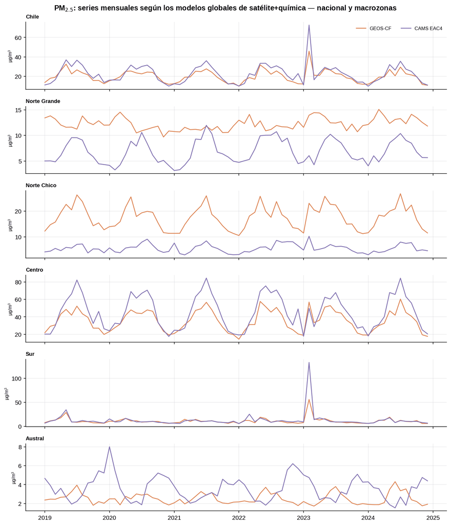

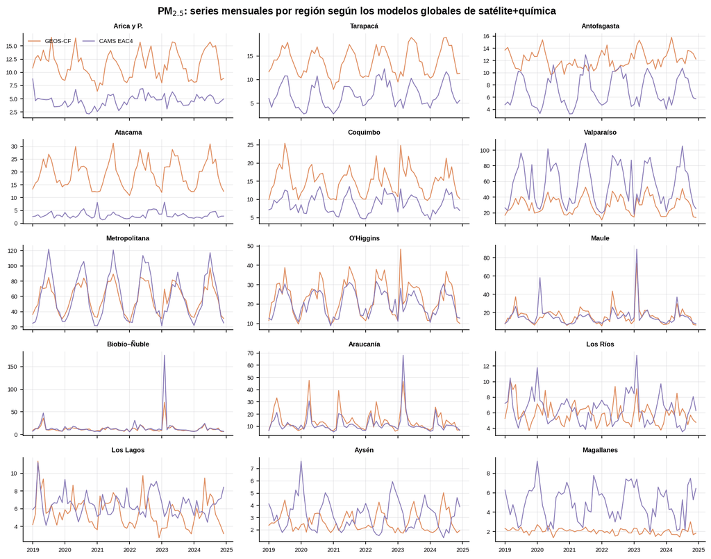

**PM₁₀**

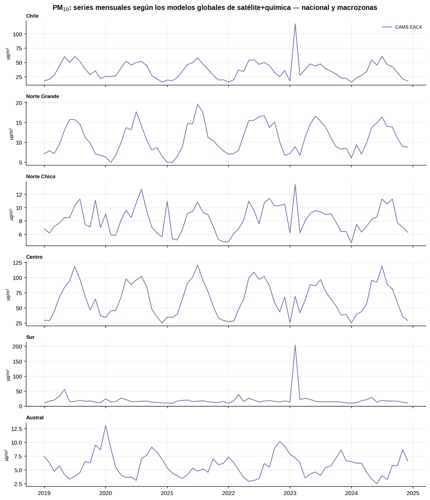

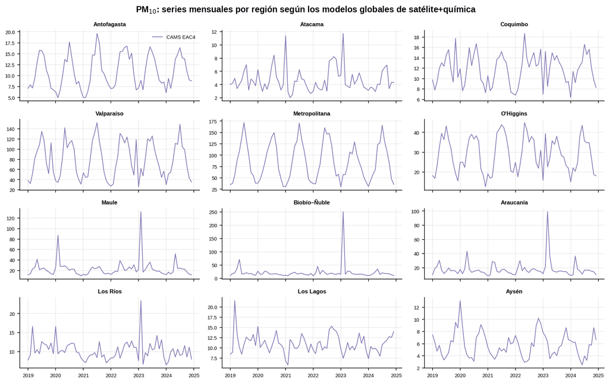

**NO₂**

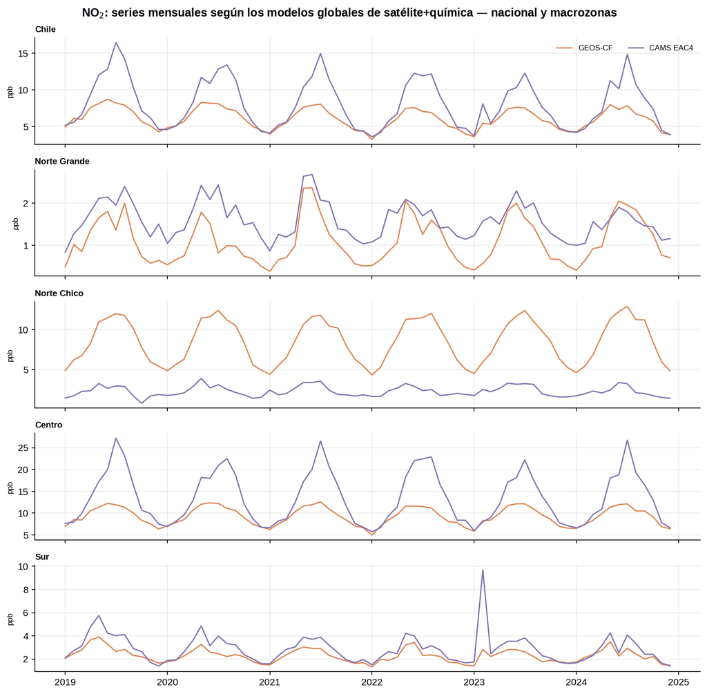

[figure not shown]

**O₃**

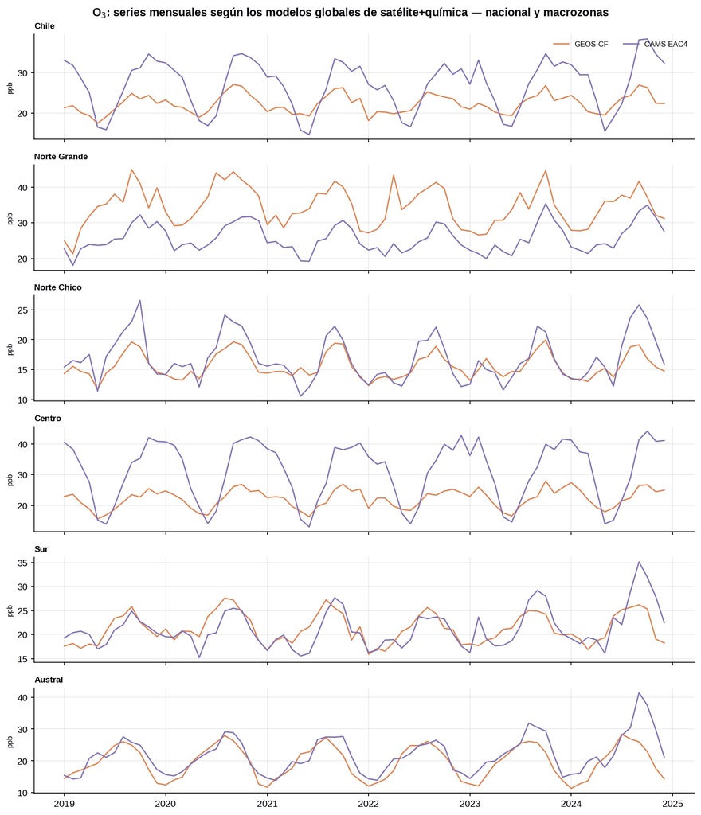

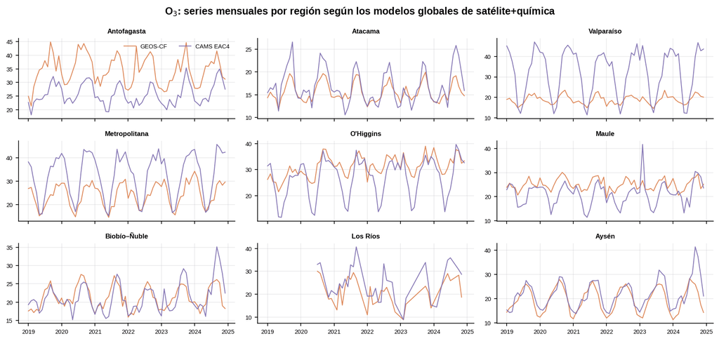

**SO₂**

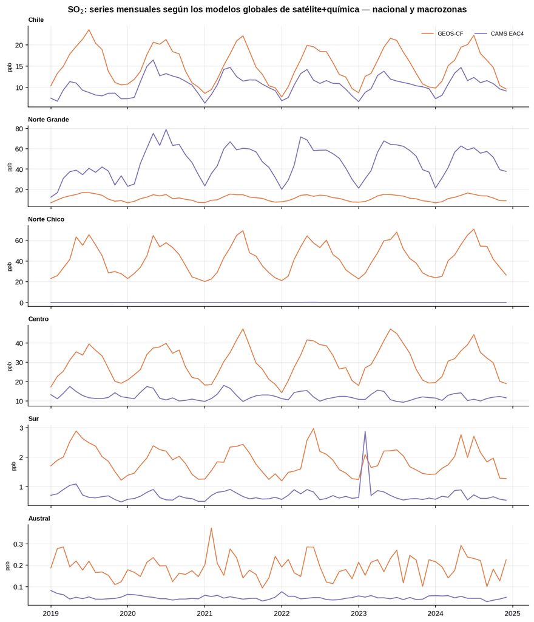

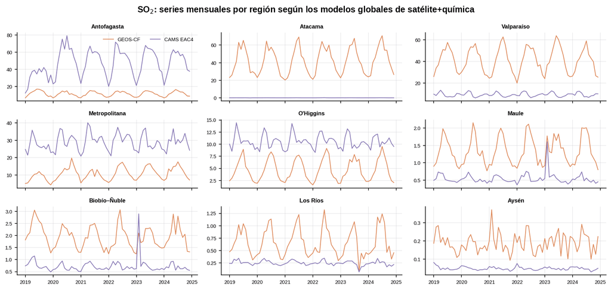

**CO**

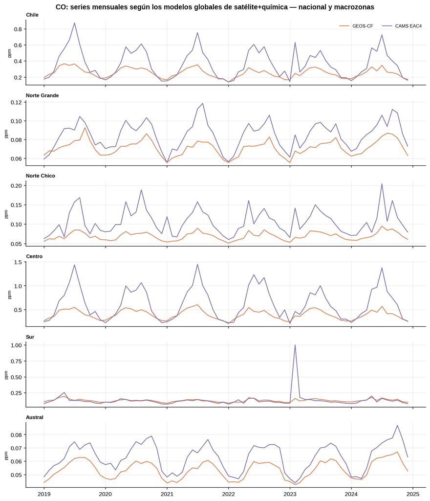

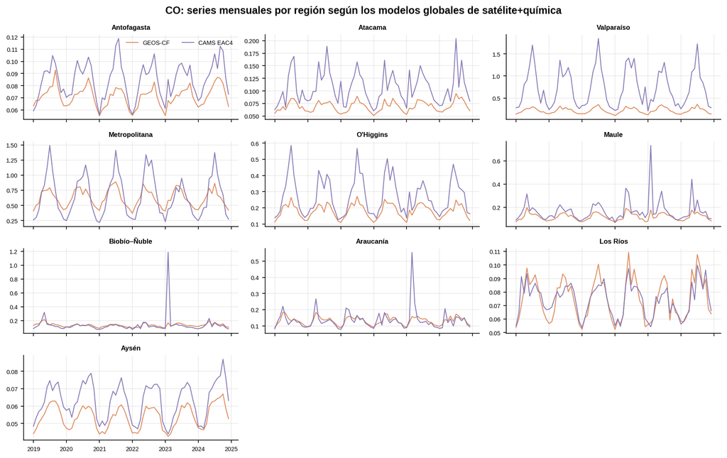

### 3.2 Series de tiempo según los monitores SINCA

**PM₂.₅**

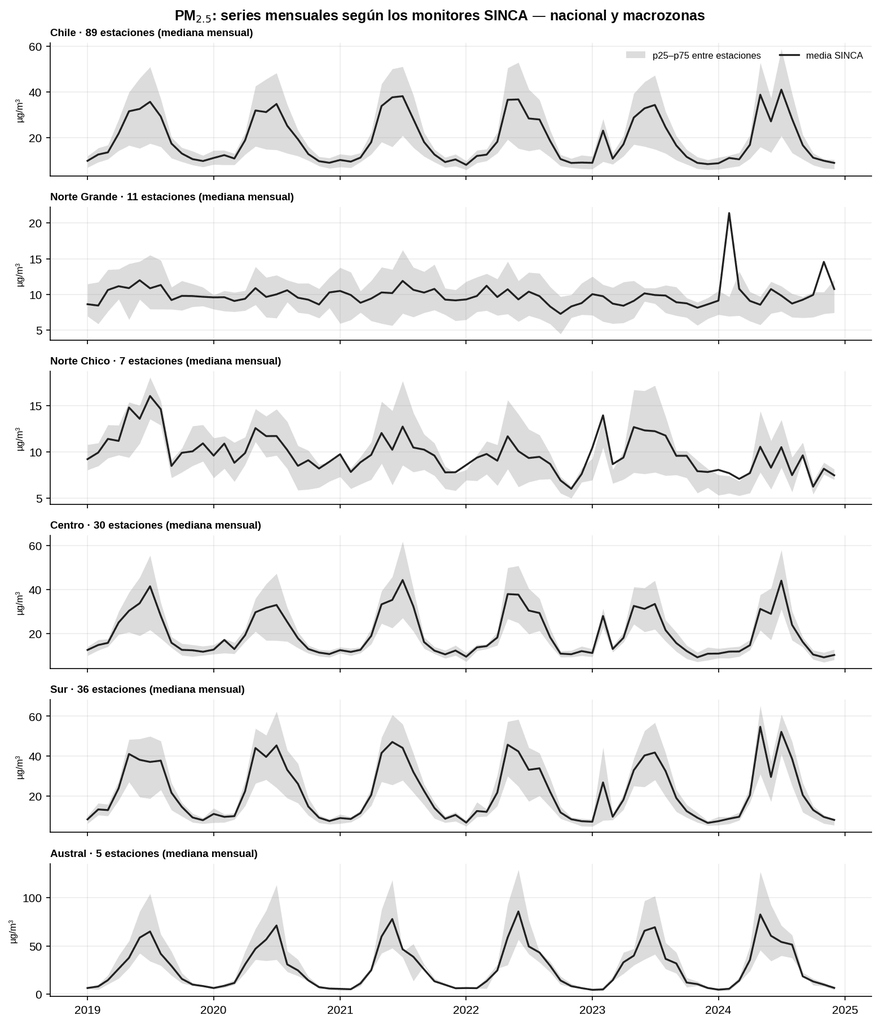

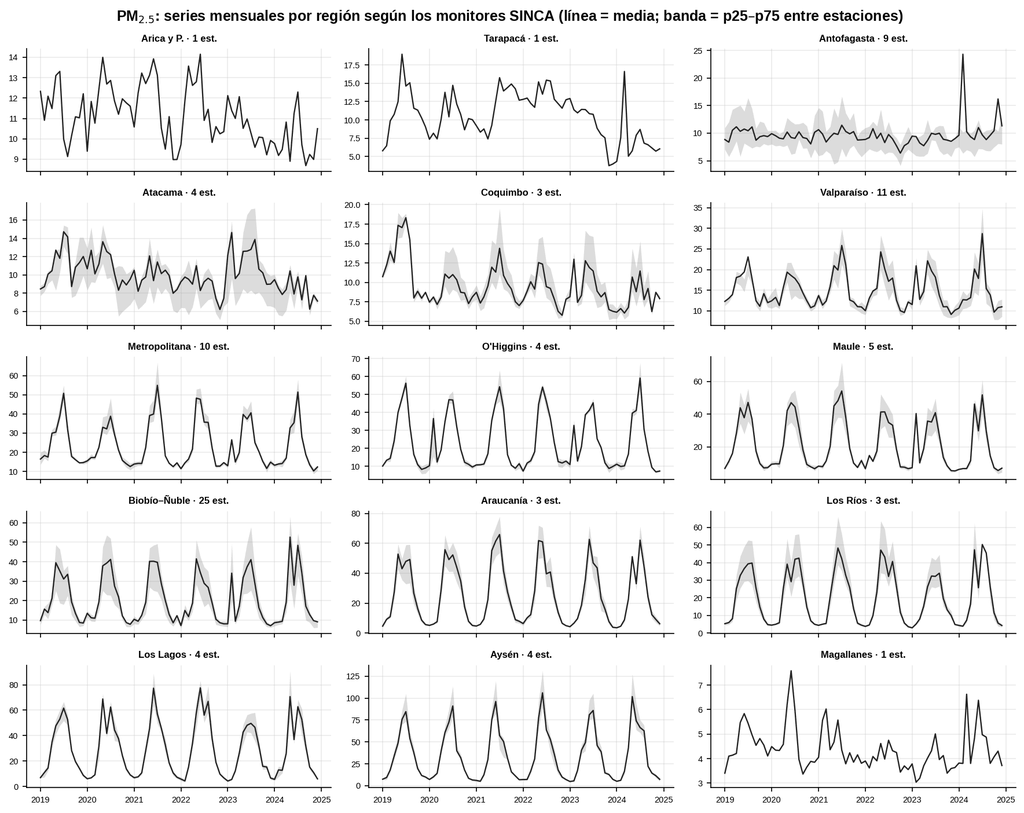

**PM₁₀**

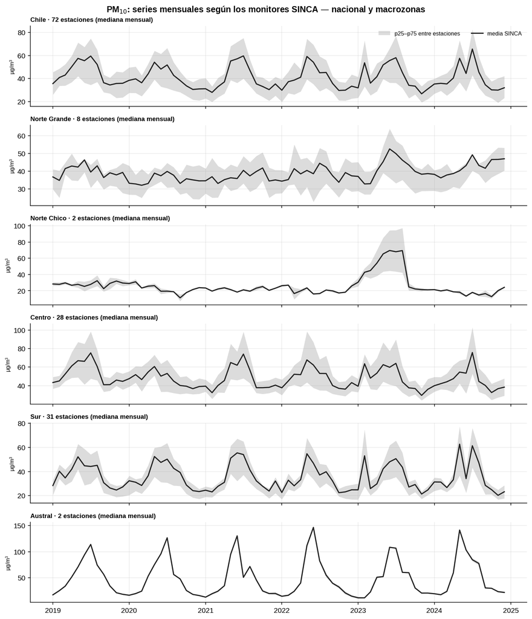

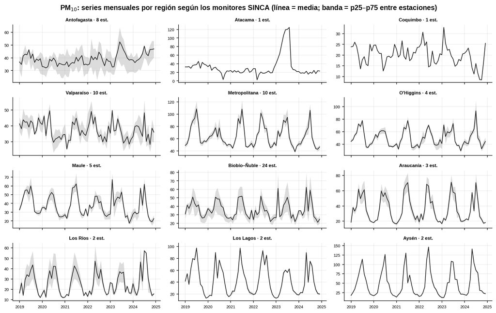

**NO₂**

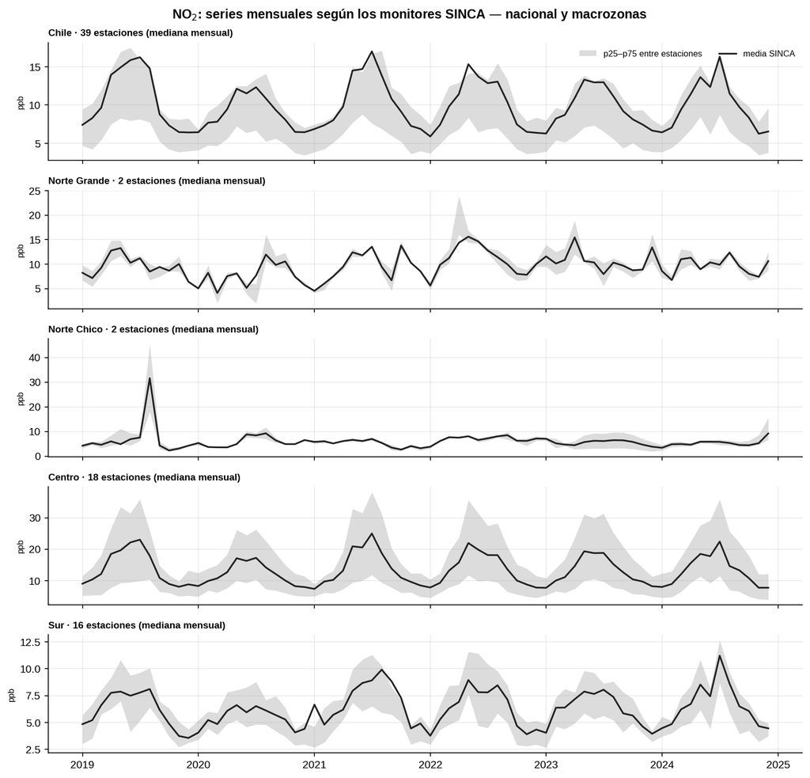

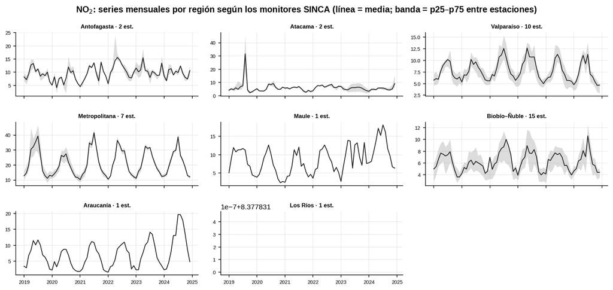

**O₃**

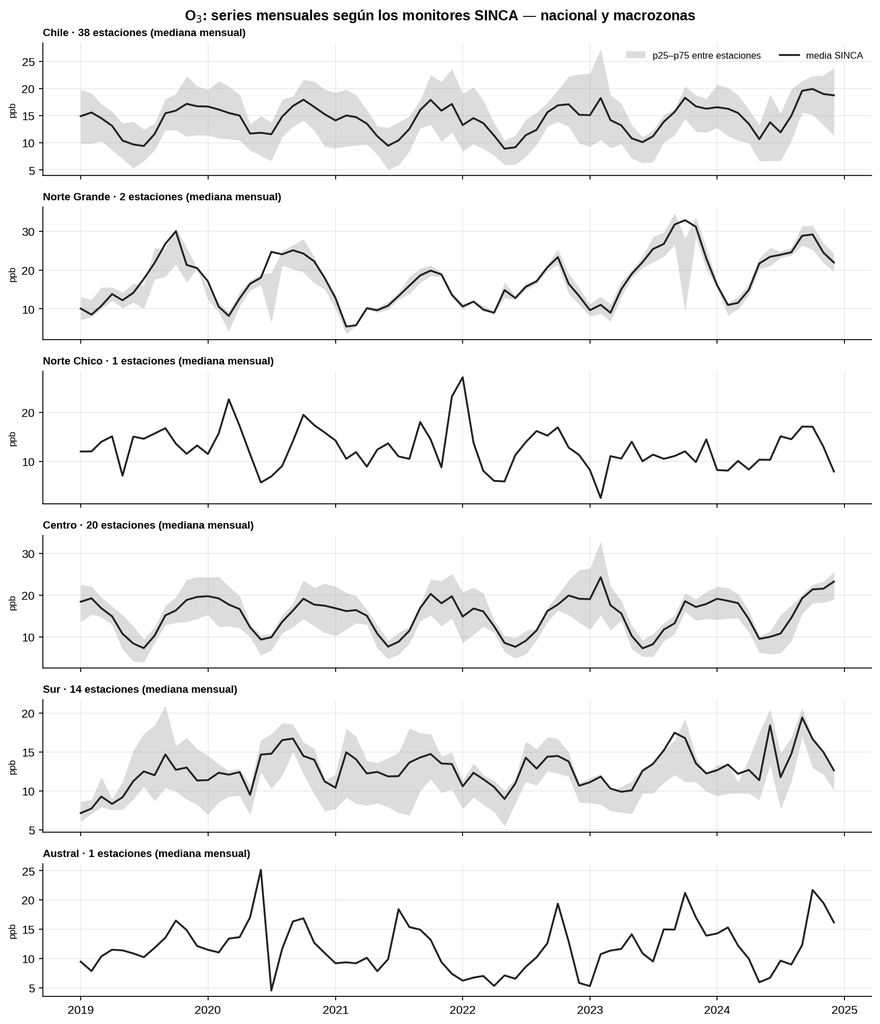

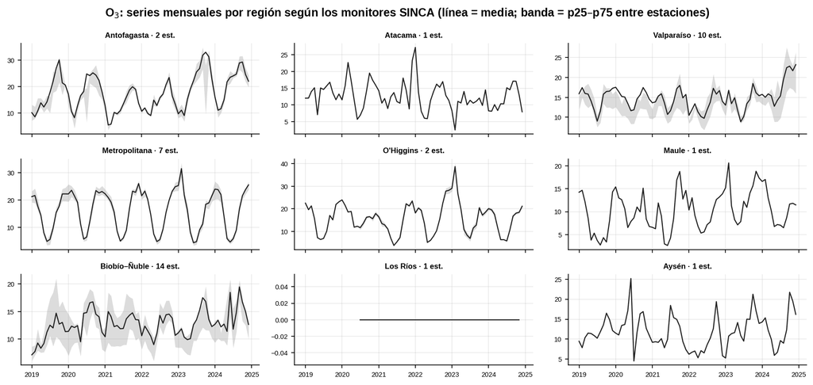

**SO₂**

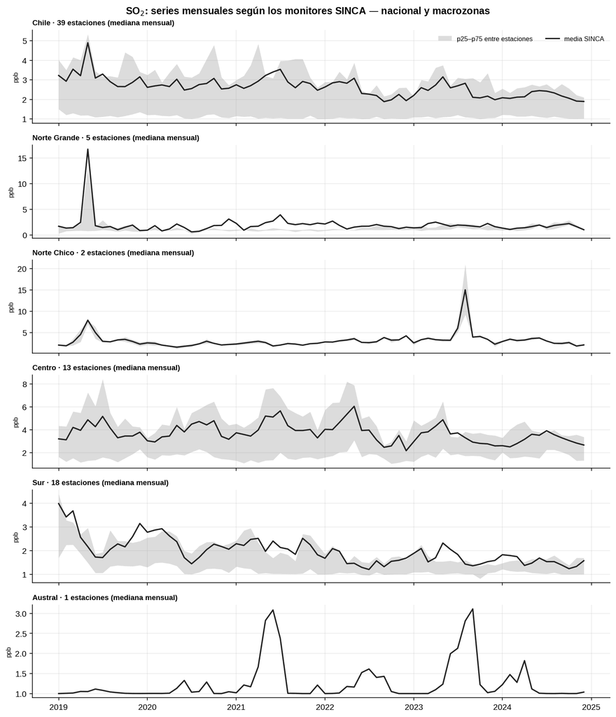

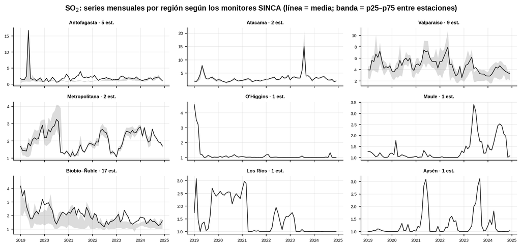

**CO**

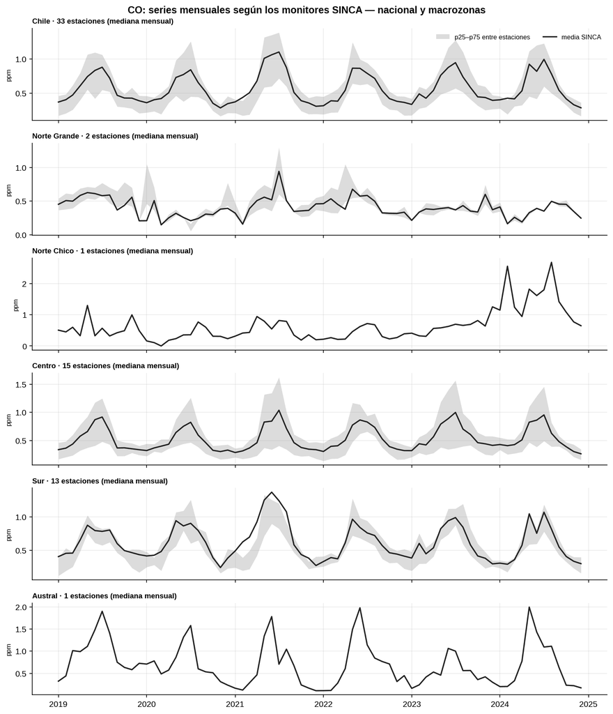

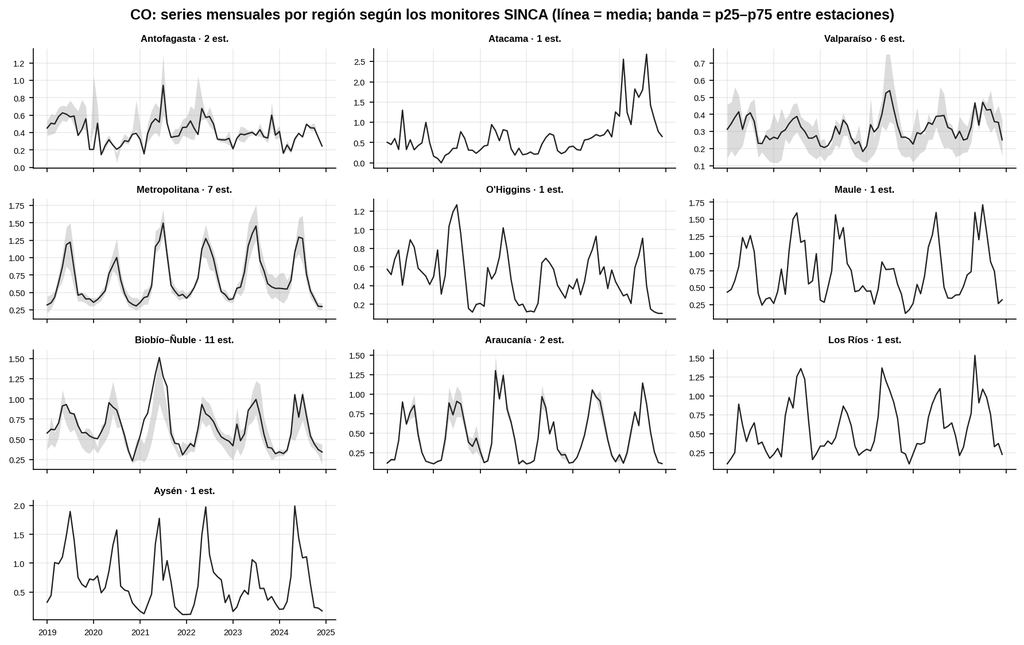

### 3.3 Correlación diaria satélite ↔︎ SINCA

Dispersión del par diario (media por estación–día) entre la observación SINCA y cada modelo global crudo, con las métricas de Sección 2.4 por nivel, y la superposición directa de ambas series como cierre.

**PM₂.₅**

#### 3.3.1 Dispersión diaria y horaria (nacional)

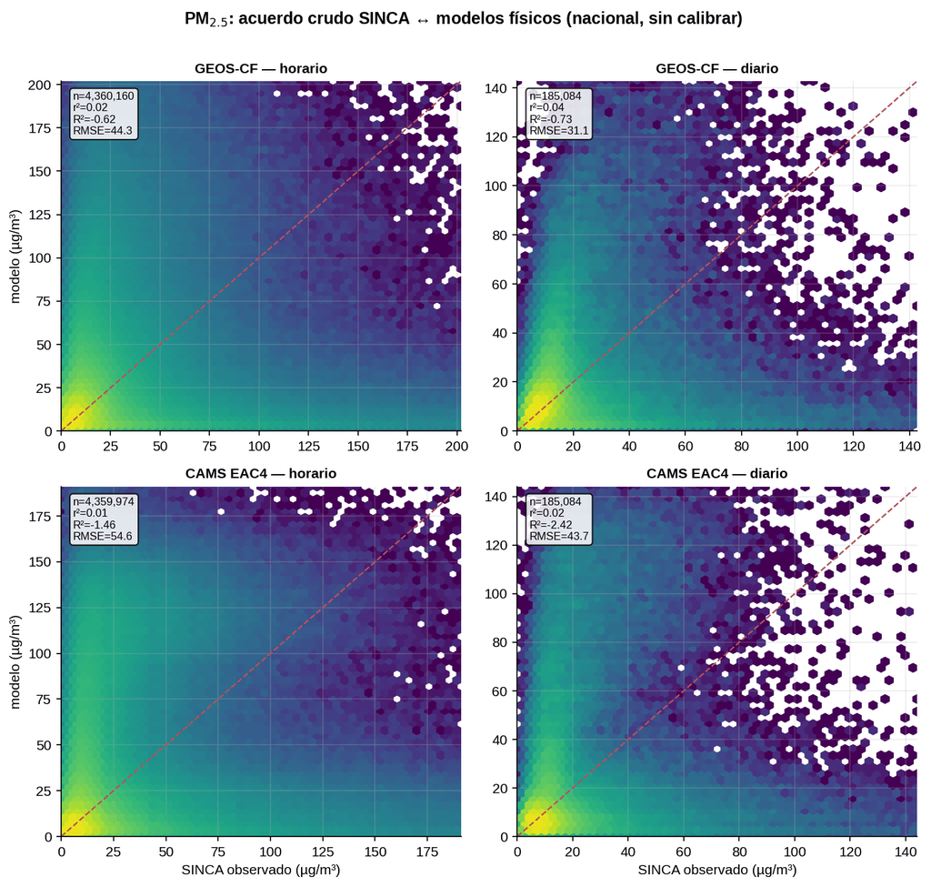

| modelo | n horario | R² horario | RMSE horario | sesgo horario | n diario | R² diario | RMSE diario | sesgo diario |
| --- | --- | --- | --- | --- | --- | --- | --- | --- |
| GEOS-CF | 4360160 | -0.623 | 44.334 | 0.712 | 185084 | -0.732 | 31.092 | 0.673 |
| CAMS EAC4 | 4359974 | -1.462 | 54.606 | 3.309 | 185084 | -2.419 | 43.689 | 3.286 |

#### 3.3.2 Por macrozona

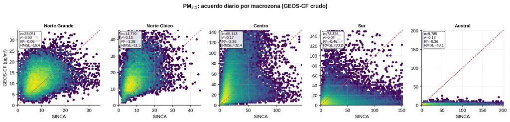

| zona | modelo | n horario | R² horario | RMSE horario | sesgo horario | n diario | R² diario | RMSE diario | sesgo diario |
| --- | --- | --- | --- | --- | --- | --- | --- | --- | --- |
| Norte Grande | GEOS-CF | 537882 | -0.067 | 19.933 | 2.297 | 23051 | -0.059 | 16.351 | 2.161 |
| Norte Grande | CAMS EAC4 | 537862 | -0.136 | 20.562 | -3.062 | 23051 | -0.17 | 17.184 | -3.174 |
| Norte Chico | GEOS-CF | 351303 | -2.05 | 15.256 | 7.768 | 14779 | -3.377 | 11.521 | 7.765 |
| Norte Chico | CAMS EAC4 | 351289 | -0.492 | 10.67 | -4.271 | 14779 | -1.074 | 7.931 | -4.262 |
| Centro | GEOS-CF | 1534335 | -2.276 | 42.967 | 15.546 | 65143 | -2.264 | 32.424 | 15.462 |
| Centro | CAMS EAC4 | 1534271 | -4.444 | 55.393 | 25.629 | 65143 | -6.206 | 48.176 | 25.58 |
| Sur | GEOS-CF | 1705316 | -0.369 | 51.629 | -10.995 | 72326 | -0.456 | 33.191 | -11 |
| Sur | CAMS EAC4 | 1705238 | -1.142 | 64.584 | -9.396 | 72326 | -2.126 | 48.637 | -9.407 |
| Austral | GEOS-CF | 231324 | -0.188 | 62.245 | -25.773 | 9785 | -0.363 | 48.093 | -25.725 |
| Austral | CAMS EAC4 | 231314 | -0.21 | 62.81 | -24.752 | 9785 | -0.4 | 48.744 | -24.698 |

#### 3.3.3 Por región

| zona | modelo | n horario | R² horario | RMSE horario | sesgo horario | n diario | R² diario | RMSE diario | sesgo diario |
| --- | --- | --- | --- | --- | --- | --- | --- | --- | --- |
| Arica y P. | GEOS-CF | 50029 | -0.156 | 8.31 | 0.38 | 2146 | -0.78 | 4.544 | 0.407 |
| Arica y P. | CAMS EAC4 | 50027 | -0.817 | 10.417 | -6.526 | 2146 | -3.921 | 7.556 | -6.496 |
| Tarapacá | GEOS-CF | 49952 | -0.175 | 11.111 | 3.242 | 2120 | -0.417 | 7.109 | 3.257 |
| Tarapacá | CAMS EAC4 | 49950 | -0.274 | 11.569 | -3.853 | 2120 | -0.573 | 7.491 | -3.829 |
| Antofagasta | GEOS-CF | 437901 | -0.064 | 21.588 | 2.409 | 18785 | -0.052 | 17.889 | 2.238 |
| Antofagasta | CAMS EAC4 | 437885 | -0.122 | 22.173 | -2.576 | 18785 | -0.149 | 18.695 | -2.72 |
| Atacama | GEOS-CF | 204838 | -2.497 | 17.514 | 9.295 | 8612 | -4.507 | 13.183 | 9.293 |
| Atacama | CAMS EAC4 | 204830 | -0.59 | 11.809 | -6.872 | 8612 | -1.609 | 9.073 | -6.863 |
| Coquimbo | GEOS-CF | 146465 | -1.149 | 11.37 | 5.632 | 6167 | -1.656 | 8.683 | 5.631 |
| Coquimbo | CAMS EAC4 | 146459 | -0.297 | 8.834 | -0.633 | 6167 | -0.261 | 5.983 | -0.63 |
| Valparaíso | GEOS-CF | 550282 | -6.269 | 32.606 | 15.082 | 23587 | -7.147 | 24.842 | 14.976 |
| Valparaíso | CAMS EAC4 | 550258 | -30.298 | 67.658 | 41.935 | 23587 | -48.507 | 61.237 | 41.687 |
| Metropolitana | GEOS-CF | 493751 | -6.408 | 57.164 | 34.206 | 20866 | -5.782 | 44.477 | 34.09 |
| Metropolitana | CAMS EAC4 | 493731 | -5.511 | 53.594 | 37.218 | 20866 | -6.296 | 46.133 | 37.08 |
| O’Higgins | GEOS-CF | 205751 | -0.015 | 30.824 | -0.091 | 8708 | 0.1 | 23.519 | -0.198 |
| O’Higgins | CAMS EAC4 | 205743 | -0.016 | 30.833 | -2.805 | 8708 | 0.075 | 23.846 | -2.913 |
| Maule | GEOS-CF | 284551 | -0.254 | 39.263 | -4.631 | 11982 | -0.165 | 25.571 | -4.641 |
| Maule | CAMS EAC4 | 284539 | -0.644 | 44.961 | -5.456 | 11982 | -0.99 | 33.416 | -5.445 |
| Biobío–Ñuble | GEOS-CF | 1187761 | -0.515 | 49.032 | -8.371 | 50538 | -0.526 | 31.133 | -8.409 |
| Biobío–Ñuble | CAMS EAC4 | 1187707 | -1.883 | 67.647 | -5.931 | 50538 | -3.346 | 52.537 | -5.988 |
| Araucanía | GEOS-CF | 162701 | -0.338 | 54.791 | -11.047 | 6837 | -0.426 | 37.041 | -11.021 |
| Araucanía | CAMS EAC4 | 162693 | -0.3 | 54.007 | -13.638 | 6837 | -0.507 | 38.072 | -13.613 |
| Los Ríos | GEOS-CF | 151472 | -0.15 | 42.268 | -14.061 | 6374 | -0.347 | 29.02 | -14.089 |
| Los Ríos | CAMS EAC4 | 151466 | -0.168 | 42.587 | -13.528 | 6374 | -0.412 | 29.705 | -13.547 |
| Los Lagos | GEOS-CF | 203382 | -0.136 | 67.657 | -23.993 | 8577 | -0.399 | 43.116 | -23.958 |
| Los Lagos | CAMS EAC4 | 203372 | -0.133 | 67.562 | -23.159 | 8577 | -0.41 | 43.281 | -23.125 |
| Aysén | GEOS-CF | 179889 | -0.251 | 70.537 | -32.48 | 7614 | -0.506 | 54.486 | -32.386 |
| Aysén | CAMS EAC4 | 179881 | -0.273 | 71.151 | -31.984 | 7614 | -0.545 | 55.201 | -31.88 |
| Magallanes | GEOS-CF | 51435 | -0.446 | 4.863 | -2.317 | 2171 | -1.083 | 3.601 | -2.364 |
| Magallanes | CAMS EAC4 | 51433 | -1.269 | 6.092 | 0.542 | 2171 | -2.538 | 4.693 | 0.492 |

#### 3.3.4 Ambas series superpuestas

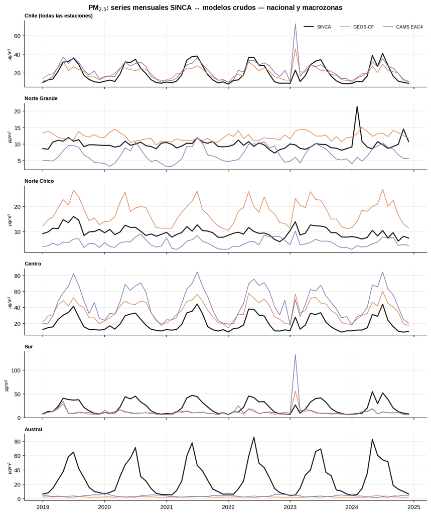

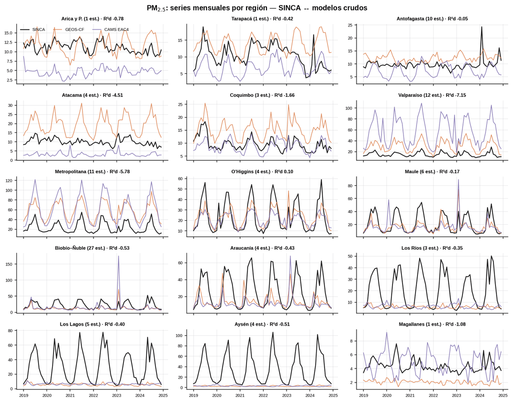

**PM₁₀**

#### 3.3.5 Dispersión diaria y horaria (nacional)

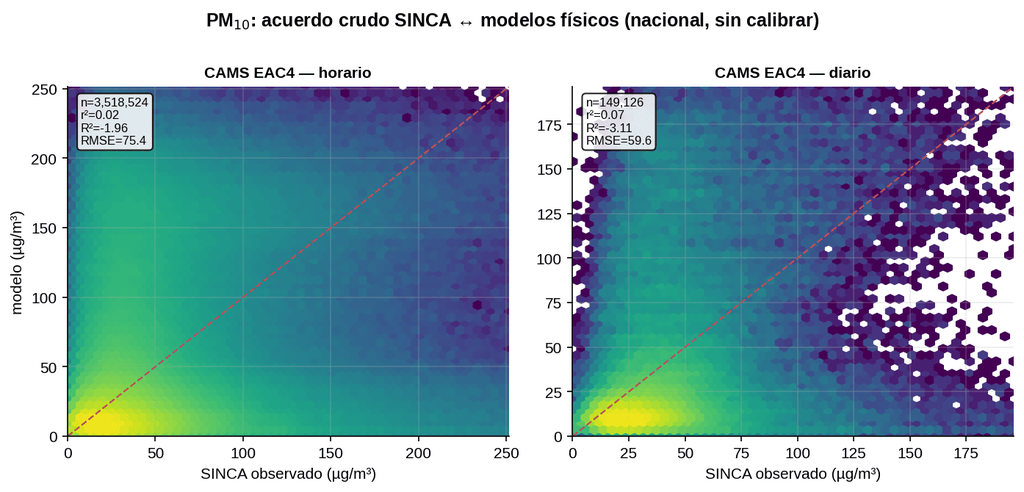

| modelo | n horario | R² horario | RMSE horario | sesgo horario | n diario | R² diario | RMSE diario | sesgo diario |
| --- | --- | --- | --- | --- | --- | --- | --- | --- |
| CAMS EAC4 | 3518524 | -1.962 | 75.379 | -4.235 | 149126 | -3.11 | 59.594 | -4.369 |

#### 3.3.6 Por macrozona

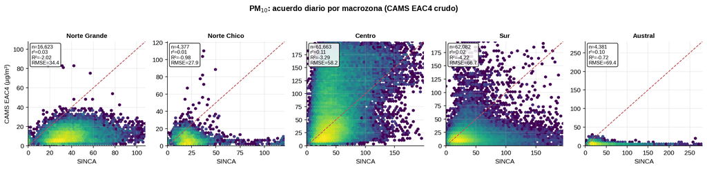

| zona | modelo | n horario | R² horario | RMSE horario | sesgo horario | n diario | R² diario | RMSE diario | sesgo diario |
| --- | --- | --- | --- | --- | --- | --- | --- | --- | --- |
| Norte Grande | CAMS EAC4 | 387834 | -0.607 | 46.134 | -28.151 | 16623 | -2.017 | 34.418 | -28.098 |
| Norte Chico | CAMS EAC4 | 104217 | -0.691 | 31.269 | -17.643 | 4377 | -0.98 | 27.924 | -17.639 |
| Centro | CAMS EAC4 | 1462464 | -2.571 | 72.436 | 16.932 | 61663 | -3.291 | 58.212 | 16.837 |
| Sur | CAMS EAC4 | 1459715 | -2.24 | 85.116 | -15.33 | 62082 | -4.224 | 66.73 | -15.394 |
| Austral | CAMS EAC4 | 104294 | -0.353 | 88.461 | -43.425 | 4381 | -0.724 | 69.421 | -43.334 |

#### 3.3.7 Por región

| zona | modelo | n horario | R² horario | RMSE horario | sesgo horario | n diario | R² diario | RMSE diario | sesgo diario |
| --- | --- | --- | --- | --- | --- | --- | --- | --- | --- |
| Antofagasta | CAMS EAC4 | 387834 | -0.607 | 46.134 | -28.151 | 16623 | -2.017 | 34.418 | -28.098 |
| Atacama | CAMS EAC4 | 52024 | -0.826 | 40.625 | -27.215 | 2185 | -1.131 | 37.437 | -27.226 |
| Coquimbo | CAMS EAC4 | 52193 | -0.692 | 17.528 | -8.102 | 2192 | -1.756 | 12.647 | -8.082 |
| Valparaíso | CAMS EAC4 | 516121 | -12.111 | 88.955 | 42.265 | 21793 | -22.863 | 77.133 | 42.141 |
| Metropolitana | CAMS EAC4 | 498941 | -1.446 | 67.445 | 21.457 | 21020 | -1.254 | 47.689 | 21.324 |
| O’Higgins | CAMS EAC4 | 206008 | -0.449 | 48.039 | -21.146 | 8705 | -0.692 | 35.707 | -21.308 |
| Maule | CAMS EAC4 | 241394 | -1.387 | 59.144 | -14.086 | 10145 | -2.438 | 44.834 | -14.083 |
| Biobío–Ñuble | CAMS EAC4 | 1119762 | -3.115 | 90.731 | -13.701 | 47778 | -5.673 | 72.362 | -13.798 |
| Araucanía | CAMS EAC4 | 155499 | -0.607 | 62.6 | -18.272 | 6533 | -1.065 | 44.068 | -18.254 |
| Los Ríos | CAMS EAC4 | 99542 | -0.178 | 44.863 | -15.323 | 4183 | -0.472 | 30.263 | -15.381 |
| Los Lagos | CAMS EAC4 | 84912 | -0.187 | 80.299 | -31.429 | 3588 | -0.597 | 52.121 | -31.448 |
| Aysén | CAMS EAC4 | 104294 | -0.353 | 88.461 | -43.425 | 4381 | -0.724 | 69.421 | -43.334 |

#### 3.3.8 Ambas series superpuestas

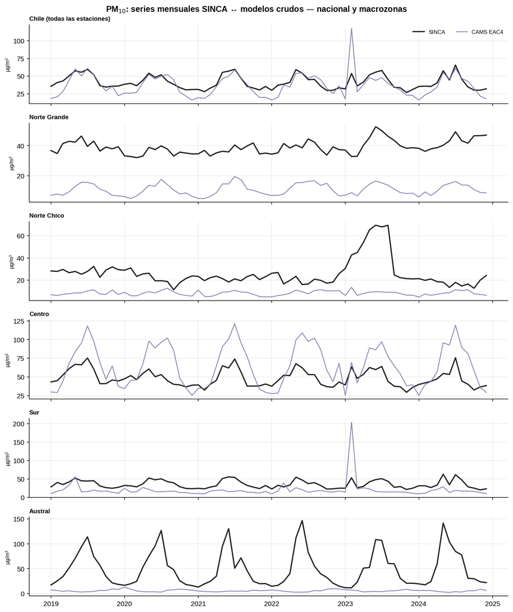

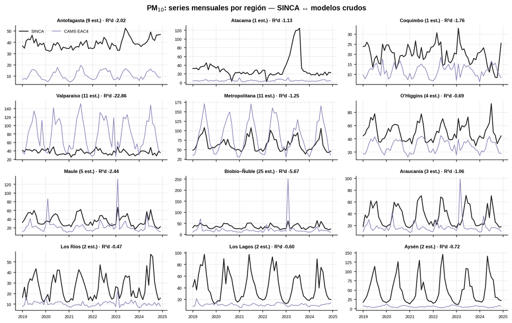

**NO₂**